# Modeling Runners’ Times in the Cherry Blossom Race

Chapter 2, Nolan & Temple Lang

John Ensley

2017-10-23

# Preface

Nolan, Deborah, and Duncan Temple Lang. 2015. *Data Science in R: A Case Studies Approach to Computational Reasoning and Problem Solving*. Chapman & Hall/CRC.

# Introduction

In this era of ‘free and ubiquitous data,’ there is tremendous potential in seeking out data to bring insight to a problem we are working on professionally or to a topic of personal interest. For example, we are interested in understanding how people’s physical performance changes as they age. One source of data about this comes from road races. Hundreds of thousands of people participate in road races each year; the race organizers collect information about the runners’ times and often publish individual-level data on the Web. These freely accessible data may provide us with insights to our question about performance and age.

One example of the many annual road races is the Cherry Blossom Ten Mile Run held in Washington D.C. in early April when the cherry trees are typically in bloom. The Cherry Blossom started in 1973 as a training run for elite runners who were planning to compete in the Boston Marathon. It has since grown in popularity and in 2012 nearly 17,000 runners ranging in age from 9 to 89 participated. The race has become so popular that entrants are chosen via a lottery or they guarantee a spot by raising $500 for an official race charity. After each year’s race, the organizers publish the results at http://www.cherryblossom.org/. These data offer a tremendous resource for learning about the relationship between age and performance.

The publicly available race results from the Cherry Blossom Ten Mile Run can be scraped from the Web and read into R [3] for analysis. The currently published results include all years from 1999 to 2012. The task of scraping the Web site and formatting the results in a way that can be analyzed in R is a bit challenging because the information reported and the format of this information changes from year to year. Some simple differences in format occur in the format of the table header and the use of footnotes. The tables also include many mistakes, e.g., values that begin in the wrong column, missing headers, and so on. All in all, the acquisition of the data is quite straightforward, but it is an iterative process as we uncover several small errors. We do this statistically, i.e., we examine summary statistics and plots of the data we have read into R, find anomalies, such as all the runners in 2003 being under 9, cross check sample observations with the original tables, modify our code to handle these problem cases in a way that is as general as possible, recreate our data, and repeat. This is the story of “messy” data. It is the focus of Section 2.2 and Section 2.3 of this chapter. Additionally, Section 2.7 covers the topic of scraping the Web for the race results, for those who are interested in the entire process of data acquisition.

After the data have been successfully read into R and cleaned, we study the relationship between run time and age in Section 2.4. Given the popularity of the race, simple tasks such as visualizing the data present challenges, and we consider how to display tens of thousands of observations in an informative manner.

For any one year of race results, we have a cross-sectional view of the performance-age relationship. That is, we are looking at different groups of people of various ages and their run times; we are not viewing an individual’s race performance as he or she gets older. However, we do have race results for 14 years and many runners have participated in multiple races. If we can associate run times over years with an individual runner, we can examine how performance changes for an individual as he or she ages. The data include the runner’s name, age, and hometown, so we consider how we might use this information to construct longitudinal views of run times for individuals. This is the subject of Section 2.5.

## Computational Topics

- Use regular expressions to extract and clean messy data from pre-formatted text tables and to create unique identifiers for matching records that belong to the same individual.
- Employ statistical techniques to identify bad data and to confirm these problems have been corrected.
- Visualize data that have a large number of observations (~150,000 records).
- Gain experience with the R formula language for plots and modeling.
- Fit piecewise linear models using least squares and non-parametric curves using local averaging.
- Compare data structures, e.g., a data frame and a list of data frames, for holding and working with longitudinal data. This includes the application of ‘apply’ functions such as `tapply()`, `mapply()`, `sapply()`, and `lapply()`.
- Develop strategies for debugging code with `recover()` for browsing active function calls after an error.
- Scrape simple Web pages for text content.

# Scraping Race Results from the Web

The race results for the Cherry Blossom Ten Mile Run are available at http://www.cherryblossom.org. The results for men in, e.g., 2012, are displayed in the screen shot in Figure @ref(fig:menresults). We see that the data are simply formatted in what appears to be a block of plain text arranged in fixed-width columns. We can examine the source code for the Web page to check if this is the case. We do this in, e.g., a Google Chrome browser by clicking on View -> Developer -> View Source. When we do this we see that the table itself contains no HTML markup, and it has been inserted into a `<pre>` node within the document. It should be very easy to extract this “table” from the HTML for further processing.

(#fig:menresults)Screen Shot of the Source for Men’s 2012 Cherry Blossom Results. This screen shot is of the HTML source for the male results for the 2012 Cherry Blossom road race. While the format is not quite the same as the female results for 2011, both are plain text tables within `<pre>` nodes in an HTML document.

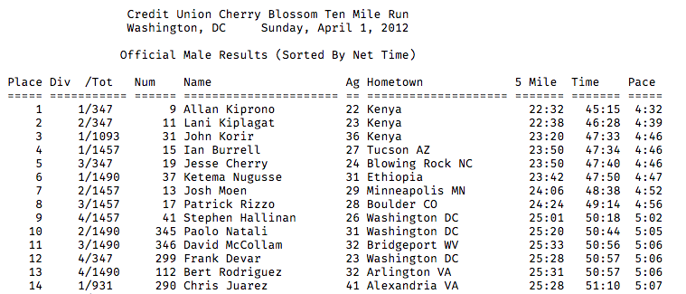

We examine one more year to ascertain if the format is the same. When we view the source for the page of 2011 women’s results, we see that the basic format is the same. A screen shot of the source for 2011 female results appears in Figure @ref(fig:womenresults). However, the columns are not identical. In 2011, a net time is reported as well as a time. And, following the pace column there is a column labeled `S`, which has an exclamation mark for the first few runners and nothing for the rest. Our task here is simply to extract the text table so we need only locate the table and extract it as a block of text. The functions in Section 2.3 take care of turning the columns of information into variables.

(#fig:womenresults)Screen Shot of the Source for Women’s 2011 Cherry Blossom Results. This screen shot is of the HTML source for the female results for the 2011 Cherry Blossom road race. Notice that times given are for the midpoint of the race (5 Mile) and for two finish times (`Time` and `Net Tim`). Also notice the rightmost column labeled `S`. While the format is different than the male results for 2012, both are plain text tables within `<pre>` nodes in an HTML document.

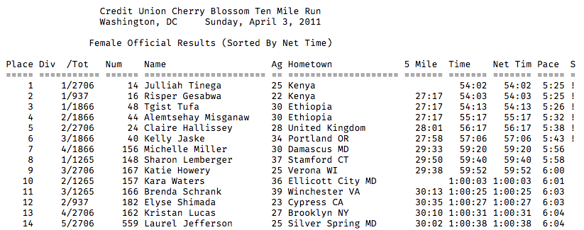

We use the `read_html()` function in the `rvest` package to scrape the 2012 men’s page from the site.

```r
ubase <- 'http://cherryblossom.org/'
url <- paste0(ubase, 'results/2012/2012cucb10m-m.htm')
doc <- read_html(url)
```

We saw from the HTML source that we want to extract the text content of the `<pre>` node. We can access all `<pre>` nodes in the document with the CSS selector `pre`.

```r
pre_node <- html_nodes(doc, 'pre')
```

The `html_nodes()` function a list where each element corresponds to one of the `<pre>` nodes in the document. In our case, there is only one such node. Next, we use the `html_text()` function to extract the text content from this node as follows:

```r
txt <- html_text(pre_node)
```

Let’s examine the contents of `txt`. We first determine how many characters it contains and then examine the start and end. We do this with

```r
nchar(txt)
```

```
## [1] 690904
```

```r
str_sub(txt, 1, 50)
```

```
## [1] "\r\n                 Credit Union Cherry Blossom Ten"
```

```r
str_sub(txt, nchar(txt) - 50, nchar(txt))
```

```
## [1] "   48 Herndon VA           1:09:06 2:30:59 15:06 \r\n"
```

It appears that we have successfully extracted the information from the web page. We also see that the individual lines end with `\r\n`. We can use these characters to split up the 690904 characters into separate strings corresponding to lines in the table. That is,

```r
els <- str_split(txt, '\\r\\n')[[1]]
```

Now we have 7202 lines of information, i.e.,

```r
length(els)
```

```
## [1] 7202
```

The first few of these contain the header information, i.e.,

```r
head(els, 3)
```

```
## [1] ""
## [2] "                 Credit Union Cherry Blossom Ten Mile Run"
## [3] "                 Washington, DC     Sunday, April 1, 2012"
```

and the last line is actually blank, but the line before that contains information for one of the runners:

```r
tail(els, 3)
```

```
## [1] " 7192              22280 Joseph White              Forestville MD       1:10:04 2:28:58 14:54 "
## [2] " 7193   648/648     6555 Lee Jordan             48 Herndon VA           1:09:06 2:30:59 15:06 "
## [3] ""
```

We have succeeded in extracting the rows of the table as elements of a character vector.

Let’s formalize our code into a function that we can apply to each of the 28 Web pages (a page for each of the men’s and women’s races from 1999 to 2012). We want our function to take as input the URL for the Web page and return a character vector with one element per line, including the header lines and the rows in the table of results. We arrange our previous code into a function as

```r
extract_res_table <- function(url) {
  read_html(url) %>%
    html_nodes('pre') %>%
    html_text() %>%
    str_split('\\r\\n') %>%
    .[[1]]
}
```

Let’s try our function with the 2012 men’s results.

```r
m2012 <- extract_res_table(url)
identical(m2012, els)
```

```
## [1] TRUE
```

Our function has extracted the same results as before. Let’s now apply it to all of the men’s results across the years.

It turns out that the URL pattern is not consistent for all the years. The correct URLs are as follows:

```r
men_urls <- c(
  'results/1999/cb99m.html',
  'results/2000/Cb003m.htm',
  'results/2001/oof_m.html',
  'results/2002/oofm.htm',
  'results/2003/CB03-M.HTM',
  'results/2004/men.htm',
  'results/2005/CB05-M.htm',
  'results/2006/men.htm',
  'results/2007/men.htm',
  'results/2008/men.htm',
  'results/2009/09cucb-M.htm',
  'results/2010/2010cucb10m-m.htm',
  'results/2011/2011cucb10m-m.htm',
  'results/2012/2012cucb10m-m.htm'
)
```

We now construct the `urls` vector so that it contains the proper web addresses. We paste the URLs together with

```r
men_urls <- paste0(ubase, men_urls)
head(men_urls, 3)
```

```
## [1] "http://cherryblossom.org/results/1999/cb99m.html"
## [2] "http://cherryblossom.org/results/2000/Cb003m.htm"
## [3] "http://cherryblossom.org/results/2001/oof_m.html"
```

Let’s try reading the results into R.

```r
men_tables <- map(men_urls, extract_res_table)
```

We receive no error messages. Of course, simply because we didn’t run into any errors, does not mean that we have properly extracted the data. We need to check the results to see if they contain the information expected.

Let’s first check the length of each of the character vectors. From the web site we have seen that several thousand runners compete each year so we expect several thousand elements in our vectors.

```r
map_int(men_tables, length)
```

```
##  [1]    1    2 3628 3728 3952 4165 4336 5245 5284 5913    1 6920 7020 7202
```

Hmm, the 1999, 2000 and 2009 extractions resulted in vectors with just one or two elements.

The file names for these three years are correct to this requires digging deeper. Let’s look at 1999 first.

```r
str_sub(men_tables[[1]], 1, 200)
```

```
## [1] "\nPLACE DIV /TOT  NAME                  AG HOMETOWN           TIME    PACE  \n===== ========= ===================== == ================== ======= ===== \n    1    1/1584 Worku Bikila          28 Ethiopia"
```

It looks like the line separators in this file are `\n` characters, not `\r\n`. This is easy enough to fix.

```r
men_tables[[1]] <- str_split(men_tables[[1]], '\\n')[[1]]
map_int(men_tables, length)
```

```
##  [1] 3194    2 3628 3728 3952 4165 4336 5245 5284 5913    1 6920 7020 7202
```

We view the source of the 2000 web page to see if it is formatted as expected. Below are the first few lines of the 2000 document, indented for better readability.

```
<html>
<body bgcolor="#CCFFFF">
 <p align="center">
  <font color="#800000" size="4" face="Arial">
    <strong>
Nortel Networks Cherry Blossom 10mile Road Race<br>
Washington, DC *** April 9, 2000
    </strong>
  </font>
  <strong>
    <font color="#800000" face="Arial">
      <br>
      <h3 align="center">
        <font color="#800000" face="Arial">
Official Results, MEN *** Gun Time Is The Official Time
        </font>
      </h3>
    <BR>
    <PRE>
      <Strong>
        </font>
        <font color="#800000" face="Courier New">
PLACE DIV /TOT  NUM   NAME                  AG ...
===== ========= ===== ===================== == ...
```

This document is not well-formed HTML. The `read_html()` function can fix many problems with malformed documents, but it can only do so much. Notice that the `<font>` and `<h3>` tags are not properly nested, and similarly the closing `</font>` tag that appears after the `<pre>` tag is problematic. If `read_html()` closes the `<pre>` tag so that the tags in the document are properly nested, then the `<pre>` node does not contain the table of race results.

We can programmatically edit the HTML so that it is well formed. Alternatively, we can try another CSS expression for locating the content for this particular file. We proceed with the second of these options and leave the first as an exercise.

If we want to handle one of the years differently than the others, then we need a way to distinguish between the two approaches. One way to do this might be to add a second argument to the function definition that indicates with which year we are working. Then our code can check the year, and if it is 2000, we can extract the table of results differently. We supply a default value to year so that if we don’t specify this argument then the function carries out the default extraction. We provide a modified `extract_res_table()` to do this:

```r
extract_res_table <- function(url, year = 2001) {
  # handle weird cases
  if (year == 1999) {
    read_html(url) %>%
    html_nodes('pre') %>%
    html_text() %>%
    str_split('\\n') %>%
    .[[1]]
  } else if (year == 2000) {
    read_html(url) %>%
    html_nodes('font') %>%
    .[[4]] %>%
    html_text() %>%
    str_split('\\r\\n') %>%
    .[[1]]
  } else {
    read_html(url) %>%
    html_nodes('pre') %>%
    html_text() %>%
    str_split('\\r\\n') %>%
    .[[1]]
  }
}
```

Since we now have two arguments to our function, we use `map2()` to call `extract_res_table()`:

```r
years <- 1999:2012
men_tables <- map2(men_urls, years, extract_res_table)
names(men_tables) <- years
map_int(men_tables, length)
```

```
## 1999 2000 2001 2002 2003 2004 2005 2006 2007 2008 2009 2010 2011 2012
## 3194 3019 3628 3728 3952 4165 4336 5245 5284 5913    1 6920 7020 7202
```

We have cleared up the problems with 1999 and 2000, but the problem with 2009 remains. It turns out that rather than putting all the data in one `<pre>` tag, each line is contained in a separate `<pre>` tag. This means that splitting the string on newline characters is unnecessary. Here is the final modified `extract_res_table()` function.

```r
extract_res_table <- function(url, year = 2001) {
  selector <- if (year == 2000) 'font' else 'pre'
  regexp <- if (year == 1999) '\\n' else '\\r\\n'

  result <- read_html(url) %>%
    html_nodes(selector)

  if (year == 2000) result <- result[[4]]

  result <- result %>%
    html_text()

  if (year == 2009) return(result)

  result %>%
    str_split(regexp) %>%
    .[[1]]
}
```

Let’s try it one more time.

```r
men_tables <- map2(men_urls, years, extract_res_table)
names(men_tables) <- years
map_int(men_tables, length)
```

```
## 1999 2000 2001 2002 2003 2004 2005 2006 2007 2008 2009 2010 2011 2012
## 3194 3019 3628 3728 3952 4165 4336 5245 5284 5913 6659 6920 7020 7202
```

Now that we have the function working for the Web pages of men’s results, we can try it on the women’s pages.

```r
women_urls <- c(
  'results/1999/cb99f.html',
  'results/2000/Cb003f.htm',
  'results/2001/oof_f.html',
  'results/2002/ooff.htm',
  'results/2003/CB03-F.HTM',
  'results/2004/women.htm',
  'results/2005/CB05-F.htm',
  'results/2006/women.htm',
  'results/2007/women.htm',
  'results/2008/women.htm',
  'results/2009/09cucb-F.htm',
  'results/2010/2010cucb10m-f.htm',
  'results/2011/2011cucb10m-f.htm',
  'results/2012/2012cucb10m-f.htm'
)

women_urls <- paste0(ubase, women_urls)
women_tables <- map2(women_urls, years, extract_res_table)
names(women_tables) <- years
map_int(women_tables, length)
```

```
## 1999 2000 2001 2002 2003 2004 2005 2006 2007 2008 2009 2010 2011 2012
## 2360 2169 2976 3339 3548 3907 4343 5445 5700 6406    1 8864 9039 9739
```

Everything worked except for 2009. It turns out that the HTML for the women’s 2009 page is properly formed, and so we don’t need the special case that we created for the men’s. We’ll modify our `extract_res_table()` function one more time.

```r
extract_res_table <- function(url, year = 2001, female = TRUE) {
  selector <- if (year == 2000) 'font' else 'pre'
  regexp <- if (year == 1999) '\\n' else '\\r\\n'

  result <- read_html(url) %>%
    html_nodes(selector)

  if (year == 2000) result <- result[[4]]

  result <- result %>%
    html_text()

  if (year == 2009 && female == FALSE) return(result)

  result %>%
    str_split(regexp) %>%
    .[[1]]
}
```

```r
men_tables <- map2(men_urls, years, extract_res_table, female = FALSE)
women_tables <- map2(women_urls, years, extract_res_table, female = TRUE)
names(men_tables) <- years
names(women_tables) <- years
map_int(men_tables, length)
```

```
## 1999 2000 2001 2002 2003 2004 2005 2006 2007 2008 2009 2010 2011 2012
## 3194 3019 3628 3728 3952 4165 4336 5245 5284 5913 6659 6920 7020 7202
```

```r
map_int(women_tables, length)
```

```
## 1999 2000 2001 2002 2003 2004 2005 2006 2007 2008 2009 2010 2011 2012
## 2360 2169 2976 3339 3548 3907 4343 5445 5700 6406 8334 8864 9039 9739
```

We save the data in text files for further processing.

```r
dir.create('men')
dir.create('women')

walk2(men_tables,
      paste('men', paste(years, 'txt', sep = '.'), sep = '/'),
      write_lines)
walk2(women_tables,
      paste('women', paste(years, 'txt', sep = '.'), sep = '/'),
      write_lines)
```

# Reading Tables of Race Results into R

Our goal in this section is to transform the raw text tables of race results into data that can be analyzed in R. These tables have been downloaded from the web and stored in files, named `1999.txt`, …, `2012.txt` in a directory called `men` for men and `women` for women. The task of downloading the Web pages and extracting the tables is addressed in Section @ref(scraping).

Let’s examine these text tables to get a sense of their format. After that we should have a few ideas about how we might extract information contained in these tables into variables for statistical analysis. Figure @ref(fig:menresults) and Figure @ref(fig:womenresults) provide screenshots of two tables as they appear on the Web. By inspection, we see that a call to `read.table()` will not properly read the text into a data frame because the information, e.g., place and division, are separated by blanks but blanks also appear in the data values, i.e., blanks also occur where they are not being used as variable separators. For example, for the runner’s hometown, we see values of `Kenya`, `Tucson AZ`, and `Blowing Rock NC`. The blanks between the different parts of hometown will confuse `read.table()`. We confirm this when we try to use `read.table()` to input the data:

```r
m2012 <- read.table('men/2012.txt', skip = 8)
```

```
## Error in scan(file = file, what = what, sep = sep, quote = quote, dec = dec, : line 1 did not have 12 elements
```

Note that we skipped the first 8 lines of the file because we observed in Figure @ref(fig:menresults) that these belong to the header of the file.

We need a customized approach to reach this ‘table.’ From the figures, it appears that the variables are formatted to occupy particular positions in each line of text. That is, the runner’s finishing place occupies the first 5 characters, then comes a blank character, the runner’s place in his or her division appears in the next 11 spaces, and so on. While the first 2 columns of the 2011 and 2012 male results line up, we see that the columns are not identical across these tables. Given the changes in formats from year to year, we can extract the values from the tables either by programmatically interpreting the format or by using year-dependent fixed-width formats. We take the first approach here and figure out which column is which by programmatically inspecting the table header. We leave the second approach as an exercise. There you examine all 28 tables, determine the start and end position of each column of interest, and use `readr::read_fwf()` to input the data into R.

Rather than view the Web pages to determine the file format, we can get a better sense of the format if we examine the raw text itself. We use `read_lines()` to read the contents of the file into R, where the return value is a character vector with one string per line of text read. We start by reading the 2012 men’s file with

```r
els <- read_lines('men/2012.txt')
```

The first 10 rows of the 2012 men’s table are

```r
head(els, 10)
```

```
##  [1] ""
##  [2] "                 Credit Union Cherry Blossom Ten Mile Run"
##  [3] "                 Washington, DC     Sunday, April 1, 2012"
##  [4] ""
##  [5] "                Official Male Results (Sorted By Net Time)"
##  [6] ""
##  [7] "Place Div  /Tot   Num    Name                   Ag Hometown             5 Mile  Time    Pace  "
##  [8] "===== =========== ====== ====================== == ==================== ======= ======= ===== "
##  [9] "    1     1/347        9 Allan Kiprono          22 Kenya                  22:32   45:15  4:32 "
## [10] "    2     2/347       11 Lani Kiplagat          23 Kenya                  22:38   46:28  4:39 "
```

We also read in and display the first 10 rows of the 2011 male results so we have another table to compare with the 2012 table. We find the following:

```r
els2011 <- read_lines('men/2011.txt')
head(els2011, 10)
```

```
##  [1] ""
##  [2] "                 Credit Union Cherry Blossom Ten Mile Run"
##  [3] "                 Washington, DC     Sunday, April 3, 2011"
##  [4] ""
##  [5] "                           Official Male Results"
##  [6] ""
##  [7] "Place Div  /Tot   Num    Name                   Ag Hometown             5 Mile  Gun Tim Net Tim Pace  "
##  [8] "===== =========== ====== ====================== == ==================== ======= ======= ======= ===== "
##  [9] "    1     1/401        3 Lelisa Desisa          21 Ethiopia                       45:36   45:36  4:34 "
## [10] "    2     2/401       13 Allan Kiprono          21 Kenya                  23:08   45:41   45:41  4:35 "
```

What do we find with this simple inspection?

- Both of the tables have a header
- The last line of the header is a row of ‘=’ characters, i.e. a separation line.
- There are blanks inserted in the row of ‘=’ characters that mark the start and end of a column of information, e.g. the Pace column occupies 5 spaces.
- The row above the ‘=’ characters gives column names.
- There are two times reported in 2011 (called `Gun Tim` and `Net Tim`) and only one time reported in 2012 (`Time`). The header of the e 2012 file tells us that `Time` is net time.

If we examine a few more years of race results, we find other differences between how the data are organized. Some years have column names that are all capitalized; do not include the time at 5 miles; contain a rightmost column that holds some sort of annotation, e.g., #; have headers consisting of 3 lines instead of 8, etc.

Let’s use the 2012 men’s results as our test case for developing the code to read in all the files. However, we will try to write the code in a general way so that it can potentially be used for all 28 files. Our first step is to find the row with the equal signs. The rows below it contain the data, the row above it holds the column headers, and the row itself supplies the spacings for the columns. We saw earlier that the ‘=’ characters are in the eighth row of the 2012 table. Since the organization of the tables differs a bit from year to year, we use a programmatic search for the equal signs. We use `str_which()` to search through the character strings in els for one that begins with, say, 3 equal signs as follows:

```r
eq_idx <- str_which(els, '^===')
```

The choice of 3 ‘=’ characters is somewhat arbitrary. We could have used just one as the equal sign does not appear elsewhere in the document.

Now that we have located this key row in the table, we extract it and the row above it and discard earlier rows with

```r
spacer_row <- els[eq_idx]
header_row <- els[eq_idx - 1]
body <- tail(els, -eq_idx)
```

Our next task is to extract the various pieces of information from each string in body, i.e., the content of the table. How might we extract the runner’s age? From inspection, a runner’s age appears in the column labeled `Ag` or `AG` so we first convert the column names to lower case so we need not search separately for `Ag` and `AG`. We use `str_to_lower()` to do this with

```r
header_row <- str_to_lower(header_row)
```

We can search through `header_row` for this two letter sequence as follows:

```r
age_location <- str_locate(header_row, 'ag')
age_location
```

```
##      start end
## [1,]    49  50
```

The return value from `str_locate()` tells us a match was found in position 49 of the character string. Now we have the information about the location of runner’s age: it begins in position 49 and ends at the 50th position in each row of the table. We use this information to extract each runner’s age using `str_sub()` as follows:

```r
age <- str_sub(body, start = age_location[1,1], end = age_location[1,2])
head(age)
```

```
## [1] "22" "23" "36" "27" "24" "31"
```

```r
summary(as.numeric(age))
```

```
##    Min. 1st Qu.  Median    Mean 3rd Qu.    Max.    NA's
##    9.00   29.00   35.00   37.75   45.00   89.00       1
```

It appears that we have located the runner’s age correctly. The youngest male runner in 2012 was 9 and the oldest was 89, and there was one runner who did not have an age reported.

We can extract all of our variables in this manner, but the width of a column might change from one year to the next so we generalize our code to search the row of equal signs for blank spaces and use the position of these to determine the locations of the columns. This approach is better than searching for variable names to find the starting position of the column of values. We find the locations of all of the blanks in the line of ‘=’ characters with

```r
blank_locs <- str_locate_all(spacer_row, ' ')[[1]][ ,1]
blank_locs
```

```
## [1]  6 18 25 48 51 72 80 88 94
```

Here the function `str_locate_all()` searches for multiple matches in the string, not just the first match. Blank spaces are found at the 6th, 18th, 25th, 48th, 51st, etc. positions.

In general, we want to write our code so that it does not depend on a variable name starting or ending in a particular column. We can extract all the columns of values using `blank_locs` to determine the start and end positions of the columns. The starting position of a column is one character past a blank and the ending position is one character before a blank. In order to properly handle the first column, we can augment `blank_locs` with 0 so the first column starts one character after 0, i.e.,

```r
search_locs <- c(0, blank_locs)
```

We can extract all the columns with `str_sub()` by

```r
values <- map(body, str_sub,
              start = head(search_locs, -1) + 1,
              end = tail(search_locs, -1) - 1)
```

We encapsulate the task of finding the starting and ending positions of the columns into a function, which we call `find_col_locs()`. In the function, we safeguard against the last character in the row of ‘=’ characters not being a blank, we add an additional element to the end of the vector of locations that is one character more than the length of the string. Our function appears as:

```r
find_col_locs <- function(spacer_row) {
  space_locs <- str_locate_all(spacer_row, ' ')[[1]][ ,1]
  row_length <- nchar(spacer_row)

  if (!str_detect(spacer_row, ' $')) {
    return(c(0, space_locs, row_length + 1))
  } else return(c(0, space_locs))
}
```

We can extract all 10 columns of data from the 2012 file, but do we want to keep all of these variables? Do we want to keep the union of all variables across the 14 years? Or, use only a subset? For now, we extract name, age, hometown, and all 3 times, i.e., gun time, net time, and time, and ignore the rest, e.g., place, div, and the 5-mile run time. We encapsulate into a function the code to extract the locations of the desired columns. We need, as inputs to this function, the names of the desired columns, the header row that contains the column names, and the locations of the blanks in the separator row. Our function follows:

```r
select_cols <- function(col_names, header_row, search_locs) {
  select_col <- function(name, header_row, search_locs) {
    start_pos <- str_locate(header_row, name)[1,1]
    if (is.na(start_pos)) return(c(NA, NA))
    index <- sum(start_pos >= search_locs)
    c(search_locs[index] + 1, search_locs[index + 1] - 1)
  }

  map(col_names, select_col,
      header_row = header_row,
      search_locs = search_locs) %>%
    do.call('rbind', .)
}
```

The encapsulation of `map()` makes it easy for us to test our code on individual column names and extract a subset of columns. For example, we can find the age variable with

```r
search_locs <- find_col_locs(spacer_row)
age_loc <- select_cols('ag', header_row, search_locs)
ages <- map_chr(body, str_sub,
                start = age_loc[ ,1],
                end = age_loc[ ,2])
summary(as.numeric(ages))
```

```
##    Min. 1st Qu.  Median    Mean 3rd Qu.    Max.    NA's
##    9.00   29.00   35.00   37.75   45.00   89.00       1
```

Our more general extraction matches the earlier one.

Another advantage to creating `select_cols()` and `find_col_locs()` is that these functions make our code modular so our code is easier to follow and to modify in the context of the larger data extraction and cleaning process.

Since the column names vary somewhat from year to year, we use only the first few characters that uniquely identify the desired columns, e.g.,

```r
short_col_names = c("name", "home", "ag", "gun", "net", "time")
```

Also, if a file does not have one of the desired variables, then we want the values for that variable to be `NA`. We can anticipate this situation because we have seen that the 2011 file has gun time and net time, but not time, and the 2012 file has a column labeled time, but no gun or net times.

```r
loc_cols <- select_cols(short_col_names, header_row, search_locs)
values <- map(body, str_sub,
              start = loc_cols[ ,1],
              end = loc_cols[ ,2]) %>%
  do.call('rbind', .)
```

Let’s examine the return value. First we check the type of the return value with

```r
class(values)
```

```
## [1] "matrix"
```

The results form a matrix of character strings. (We have not yet converted any values such as age to numeric.) We see that the first few rows of the matrix are

```r
colnames(values) <- short_col_names
head(values)
```

```
##      name                     home                   ag   gun net
## [1,] "Allan Kiprono         " "Kenya               " "22" NA  NA
## [2,] "Lani Kiplagat         " "Kenya               " "23" NA  NA
## [3,] "John Korir            " "Kenya               " "36" NA  NA
## [4,] "Ian Burrell           " "Tucson AZ           " "27" NA  NA
## [5,] "Jesse Cherry          " "Blowing Rock NC     " "24" NA  NA
## [6,] "Ketema Nugusse        " "Ethiopia            " "31" NA  NA
##      time
## [1,] "  45:15"
## [2,] "  46:28"
## [3,] "  47:33"
## [4,] "  47:34"
## [5,] "  47:40"
## [6,] "  47:50"
```

The 2012 table has a column for time and not gun and net times so the gun and net values are NA. We also check the last few lines with

```r
tail(values)
```

```
##         name                     home                   ag   gun net
## [7188,] "Dana Brown            " "Randallstown MD     " "41" NA  NA
## [7189,] "Jurek Grabowski       " "Fairfax VA          " "39" NA  NA
## [7190,] "Larry Hume            " "Arlington VA        " "56" NA  NA
## [7191,] "Sean-Patrick Alexander" "Alexandria VA       " "35" NA  NA
## [7192,] "Joseph White          " "Forestville MD      " "  " NA  NA
## [7193,] "Lee Jordan            " "Herndon VA          " "48" NA  NA
##         time
## [7188,] "2:26:47"
## [7189,] "2:27:11"
## [7190,] "2:27:20"
## [7191,] "2:27:30"
## [7192,] "2:28:58"
## [7193,] "2:30:59"
```

Here we see the one runner who did not report an age. It appears that we have successfully captured the information from the table in `men/2012.txt`.

We wrap up the process of extracting the columns into a function so we can apply it to each year’s data. This function calls our helper functions `find_col_locs()` and `select_cols()`. Our function might look like

```r
extract_variables <- function(file, var_names = c("name", "home", "ag", "gun", "net", "time")) {
  # find the index of the row with =s
  eq_idx <- str_which(file, '^===')
  # extract the two key rows and the data
  spacer_row <- file[eq_idx]
  header_row <- file[eq_idx - 1] %>% str_to_lower()
  body <- tail(file, -eq_idx)

  # get starting and ending positions of variables
  search_locs <- find_col_locs(spacer_row)
  loc_cols <- select_cols(var_names, header_row, search_locs)
  values <- map(body, str_sub, loc_cols) %>% do.call('rbind', .)
  colnames(values) <- var_names
  invisible(values)
}
```

We are ready to create the data frames for each year, but the `extract_variables()` function expects the file passed to it for the extraction to be a character vector. We first must read the lines of the tables into R. We do this with:

```r
mfilenames <- list.files('men', pattern = '.txt$', full.names = TRUE)
men_files <- map(mfilenames, read_lines)
names(men_files) <- str_match(mfilenames, 'men/(.*).txt')[ ,2]
```

Similarly, we can read the women’s results into `women_files`.

```r
wfilenames <- list.files('women', pattern = '.txt$', full.names = TRUE)
women_files <- map(wfilenames, read_lines)
names(women_files) <- str_match(wfilenames, 'women/(.*).txt')[ ,2]
```

These two objects, `men_files` and `women_files`, are lists where each list contains 14 character vectors, one for each year. Each of these character vectors contains one string for every row in the corresponding file.

We can now apply the `extract_variables()` function to `men_files` and `women_files` to obtain a list of character matrices. We do this for the men’s list with

```r
men_res_mat <- map(men_files, extract_variables)
length(men_res_mat)
```

```
## [1] 14
```

```r
map_int(men_res_mat, nrow)
```

```
## 1999 2000 2001 2002 2003 2004 2005 2006 2007 2008 2009 2010 2011 2012
## 3190 3017 3589 3724 3948 4156 4327 5237 5276 5905 6651 6911 7011 7193
```

and for the women’s list with

```r
women_res_mat <- map(women_files, extract_variables)
```

```
## Error: length(n) == 1L is not TRUE
```

Unfortunately, there is a problem with one of the women’s files. In 2001, the separator row of ‘=’ characters does not exist!

```r
head(women_files$`2001`)
```

```
## [1] ""
## [2] "                                                                 "
## [3] "                      "
## [4] "    1  6002 Elana MEYER           34 Rep Of S.africa      52:15   52:16#"
## [5] "    2  6004 Lydia GRIGORIEVA      27 Russia               53:12   53:15#"
## [6] "    3  6019 Eyerusalem KUMA       20 Ethiopia             53:16   53:19#"
```

It looks as though the women’s file shares the same header as the men’s 2001 file. The men’s file did load correctly, so I will cheat a little bit and manually parse the women’s file with the header information from the men’s file.

```r
men_file_2001 <- men_files$`2001`
women_file_2001 <- women_files$`2001`

eq_idx_2001 <- str_which(men_file_2001, '^===')
spacer_row_2001 <- men_file_2001[eq_idx_2001]
header_row_2001 <- men_file_2001[eq_idx_2001 - 1] %>% str_to_lower()

women_files$`2001`[2] <- header_row_2001
women_files$`2001`[3] <- spacer_row_2001
```

Let’s try parsing the women’s files again.

```r
women_res_mat <- map(women_files, extract_variables)
length(women_res_mat)
```

```
## [1] 14
```

```r
map_int(women_res_mat, nrow)
```

```
## 1999 2000 2001 2002 2003 2004 2005 2006 2007 2008 2009 2010 2011 2012
## 2356 2167 2973 3335 3544 3899 4334 5437 5692 6397 8325 8855 9030 9730
```

We see that we get reasonable values for the number of rows in our matrices. Our next task is then to convert these character matrices into a format that we can readily analyze. As we do this, we use statistics to check the results and find that additional data cleaning is necessary. This is the topic of the next chapter.

# Data Cleaning and Reformatting Variables

In this section, we consider how to convert the list of character matrices, `men_res_mat`, into an appropriate format for analysis. Currently, the data values are all character, which is not conducive to, e.g., finding the median age of the runners. However, we can easily reformat age into numeric values with the `as.numeric()` function. Do we want to turn the entire matrix into a numeric matrix? Not really. It doesn’t make sense to try to convert the runner’s name into a numeric value. For this reason, we want to create a data frame because it allows our variables to be different types. We have 6 variables: the runner’s name, home town, age, and 3 versions of time. As just mentioned, we want to convert age to a numeric and leave name as character. What about the other variables? We probably want to also keep hometown as character.

Time is stored as a string in the format: `hh:mm:ss`. We want time in a numeric format so it can be more easily summarized and modeled. For this, we will use the `lubridate` package, which is excellent for converting character strings to dates and times. We also need to reconcile the 3 different recorded times (gun, net, and plain time). Net time is considered more accurate than gun time so we can simply use net time when available and otherwise use gun time or time, whichever is reported. Of course, we can keep all 3 versions of time around and let the analyst explore relationships between them and decide which to use, but we keep things simple for now and just report one time for each runner.

Before we begin converting our character strings into numeric values, we also consider whether there are any new variables we might want to create. If we are to combine all the data from the 14 years of records into one data frame, then we should keep track of the year. Likewise, if we are to combine the men’s and women’s results then we also want a variable that indicates the sex of the runner. These are very simple to make when combining data frames with `dplyr::bind_rows()`.

We begin with the task of creating the numeric variable `age` with `as.numeric()`, e.g., for the 2012 males,

```r
age <- as.numeric(men_res_mat$`2012`[ ,'ag'])
```

Note that we subsetted the list to work with the 2012 matrix and then subsetted this matrix to work with the column named `ag`. We check a few `age` values with

```r
tail(age)
```

```
## [1] 41 39 56 35 NA 48
```

These values look reasonable, but let’s check more thoroughly that our data extraction works as expected by summarizing each year’s ages with

```r
age <- map(men_res_mat, ~ as.numeric(.x[ ,'ag']))
```

```
## Warning in .f(.x[[i]], ...): NAs introduced by coercion

## Warning in .f(.x[[i]], ...): NAs introduced by coercion

## Warning in .f(.x[[i]], ...): NAs introduced by coercion
```

We received a warning message that our conversion of the character values for age into numeric resulted in `NA` values, meaning that some of the values do not correspond to numbers. We want to look into the specific cause of these messages, but first we examine `age`.

We create side-by-side boxplots of the yearly distribution of the age of the runners to give a quick check on the reasonableness of the values.

```
## Warning: Removed 66 rows containing non-finite values (stat_boxplot).
```

(#fig:ageboxplot)Box Plot of Age by Year. These side-by-side boxplots of age for each race year show a few problems with the data for 2003 and 2006. The runners in these years are unusually young.

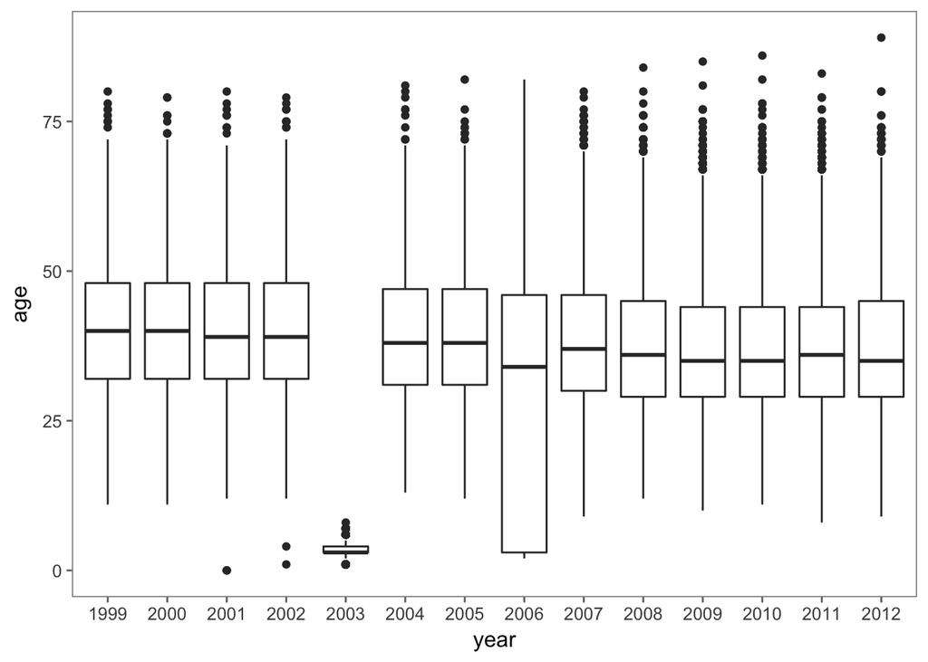

```r
age %>%
  enframe(name = 'year', value = 'age') %>%
  unnest() %>%
  ggplot(aes(year, age)) +
  geom_boxplot()
```

Figure @ref(fig:ageboxplot) reveals problems with 2 years. All of the runners in 2003 were under 10 and more than 1 in 4 runners in 2006 were under 10! Clearly something has gone wrong.

Let’s examine the original text for 2003 and 2006.

```r
head(men_files$`2003`)
```

```
## [1] ""
## [2] "Place Div /Tot  Num    Name                          Ag Hometown            Gun Tim  Net Tim "
## [3] "===== ========= ===== ============================= == =================== =======  ======= "
## [4] "    1    1/1999     6  John Korir                    27  KEN                  46:56#   46:55 "
## [5] "    2    2/1999     1  Reuben Cheruiyot              28  KEN                  47:03#   47:02 "
## [6] "    3    3/1999     8  Gilbert Okari                 24  KEN                  47:07#   47:07 "
```

```r
men_files$`2006`[2200:2205]
```

```
## [1] " 2192 1263/2892   1475 Matt Curtis            39 Vienna          1:27:08 1:27:40   8:46   "
## [2] " 2193  94/279    1437 Joe McCloskey          59 Columbia        1:27:01 1:27:40   8:46   "
## [3] " 2194 257/590    7062 Donald Hofmann         48 Princeton Junct 1:25:45 1:27:41   8:47   "
## [4] " 2195 1264/2892   7049 Claudio Petruzziello   23 Princeton Jct   1:25:45 1:27:41   8:47   "
## [5] " 2196 339/746    3319 Robert Morrison        40 South Boston    1:23:54 1:27:41   8:47   "
## [6] " 2197 1265/2892   9345 Larry Cooper           32 Arlington       1:26:42 1:27:41   8:47   "
```

We see that in 2003, the age values are shifted to the right one space in comparison to the location of the ‘=’ characters. This means that we are picking up only the digit in the tens place. In 2006, some but not all of the rows have values that are off by one character.

We can easily solve both of these problems by including the value in the “blank” space between columns. We can do this by changing the index for the end of each variable when we perform the extraction. That is, we modify the line in `select_cols()` that locates the end of a column to include the blank position, i.e.,

```r
select_cols <- function(col_names, header_row, search_locs) {
  select_col <- function(name, header_row, search_locs) {
    start_pos <- str_locate(header_row, name)[1,1]
    if (is.na(start_pos)) return(c(NA, NA))
    index <- sum(start_pos >= search_locs)
    c(search_locs[index] + 1, search_locs[index + 1])
  }

  map(col_names, select_col,
      header_row = header_row,
      search_locs = search_locs) %>%
    do.call('rbind', .)
}
```

When we use this revised calculation in `select_cols()`, we pick up the blank character after each field. This should not matter when we convert our text data to numeric and if we don’t want trailing blanks in our character-valued variables, we can easily remove them with regular expressions.

In the process of confirming our conversion of age from character to numeric, we uncovered problems with our extraction process. We need to modify our helper function `select_cols()` from Chapter @ref(reading) to address the problem. This process is iterative as we continue to check that our data make sense. When we uncover nonsensical results, we investigate them further, which possibly leads to retracing our steps to clean up messy data.

After we modify this one line of code in `select_cols()` and reapply this updated version of the function to the tables of race results, we check again the summary statistics with boxplots. We find that the problem with too many young runners has cleared up (see Figure @ref(fig:ageboxplots-fixed)).

```
## Warning: Removed 64 rows containing non-finite values (stat_boxplot).
```

(#fig:ageboxplots-fixed)Box Plot of Age by Year. These side-by-side boxplots of age for each race year show a reasonable age distribution. For example, the lower quartile for all years range between 29 and 32. The problems identified earlier for 2003 and 2006 have been addressed.

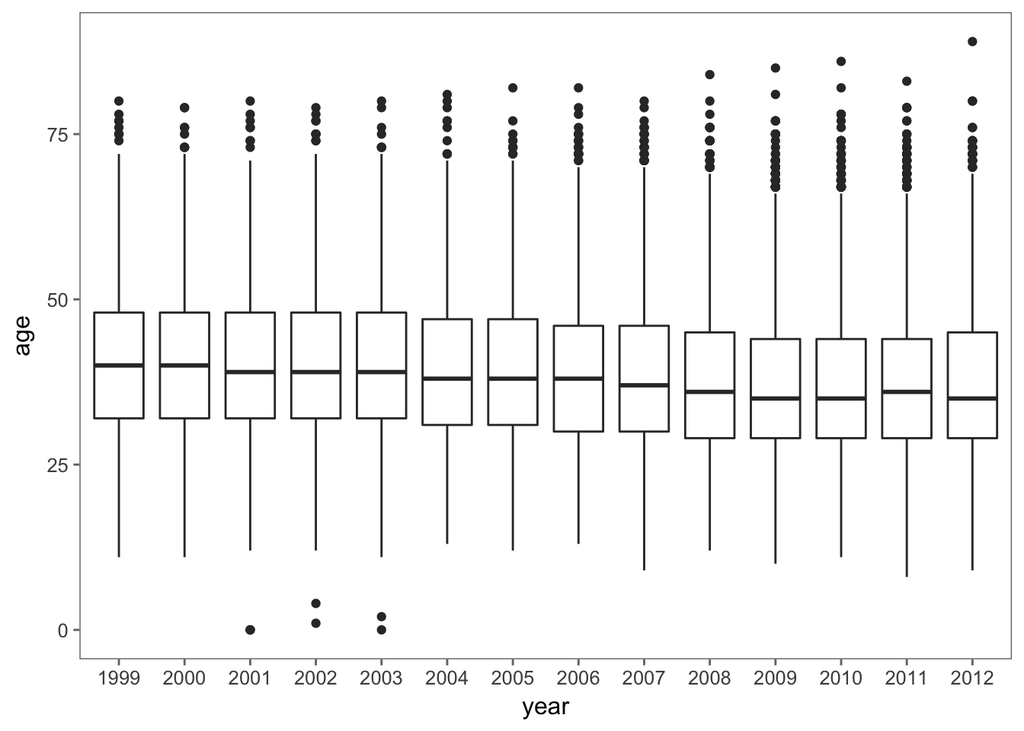

We now turn to the warning messages that occurred when we converted the character strings for age to numeric values. We were given several messages ‘NAs introduced by coercion’. We count the number of `NA` values in each year with

```r
map_int(age, ~ sum(is.na(.)))
```

```
## 1999 2000 2001 2002 2003 2004 2005 2006 2007 2008 2009 2010 2011 2012
##    1    1   28    3    2    0   13    2    5    0    2    6    0    1
```

```r
age2001 <- age$`2001`
```

Let’s examine the original rows in the file that correspond to an `NA` in `age2001`. Recall that we dropped the header of the file before extracting the variables so we need to add an offset to the location of the `NA`s in `age2001` in order to pick out the correct rows in the original table. We find the offset with

```r
offset <- str_which(men_files$`2001`, '^===')
offset
```

```
## [1] 5
```

We then find the lines in the original file that have the bad age values with

```r
bad_age_idx <- which(is.na(age2001)) + offset
tail(men_files$`2001`[bad_age_idx])
```

[output not shown]

To save space, only the last few lines are shown here. With one exception, all of the rows are blank/empty. The one exception is the row that corresponds to the footnote that defines the meaning of the ‘#’ annotation. Where in the table are these rows located?

```r
bad_age_idx
```

```
##  [1] 1756 1757 1758 1759 1810 1811 1812 1813 1864 1865 1866 1867 1918 1919
## [15] 1920 2521 2522 2523 2524 2875 2876 2877 2878 2979 2980 2981 2982 3594
```

These blank lines are scattered throughout the file. We can modify the extraction by checking for blank rows and removing them. The regular expression,

```r
blanks <- str_which(men_files[['2001']], '^[[:blank:]]*$')
```

locates all rows that are entirely blank. The second argument to `str_which` uses several meta characters to specify the pattern to search for. The `^` is an anchor for denoting the start of the string, the `$` anchors to the end of the string, the `[[:blank:]]` denotes the equivalence class of space and tab characters, and the `*` indicates that the blank character can appear 0 or more times. All together the pattern `^[[:blank:]]*$` matches a string that contains any number of blanks from start to end, i.e., only blank lines.

A simpler expression locates the footnote rows, i.e., rows that begin with # or *. Here is the modified `extract_variables()` function:

```r
extract_variables <- function(file, var_names = c("name", "home", "ag", "gun", "net", "time")) {
  # find the index of the row with =s
  eq_idx <- str_which(file, '^===')
  # extract the two key rows and the data
  spacer_row <- file[eq_idx]
  header_row <- file[eq_idx - 1] %>% str_to_lower()
  # find blank lines
  blanks <- str_which(file, '^[[:blank:]]*$')
  # find comments
  comments <- str_which(file, '^[[:blank:]]*[#\\*]')
  # remove header, blank lines, and comments
  body <- file[-c(1:eq_idx, blanks, comments)]

  # get starting and ending positions of variables
  search_locs <- find_col_locs(spacer_row)
  loc_cols <- select_cols(var_names, header_row, search_locs)
  values <- map(body, str_sub, loc_cols) %>% do.call('rbind', .)
  colnames(values) <- var_names
  invisible(values)
}
```

```r
map_int(age, ~ sum(is.na(.)))
```

```
## 1999 2000 2001 2002 2003 2004 2005 2006 2007 2008 2009 2010 2011 2012
##    1    1   28    3    2    0   13    2    5    0    2    6    0    1
```

Continued inspection of Figure @ref(fig:ageboxplots-fixed) uncovers another problem – the minimum values for age in 2001, 2002, and 2003 remain small, i.e., close to 0. That’s clearly not possible! Let’s find which runners have an age under 5 and look at their records in the original table. For 2001, we have

```r
which(age2001 < 5)
```

```
## [1] 1377 3030 3079
```

```r
men_files[['2001']][which(age2001 < 5) + offset]
```

```
## [1] " 1377  5629 Steve PINKOS           0 Washington DC      1:20:07 1:22:34"
## [2] " 2970  5332 Kurt MENKE            38 Springfield VA     1:38:07 1:40:50"
## [3] " 3019  5199 Thomas HAMMER         53 Falls Church VA    1:39:05 1:41:41"
```

Apparently there are runners with an age entered as 0! Since these are the actual values in the table, we leave the decision as to what to do with these runners for later when we analyze the data. At this point, it appears we have successfully taken care of the creation of the age variable. However, we typically clean the variables simultaneously as an error in one variable often leads to errors in others based on position. As we clean the other variables, we may need to re-examine age to ensure that the values for age remain valid.

Next, we turn to the creation of the time variable. As mentioned at the beginning of this section, the time appears as `hh:mm:ss` and we wish to convert it to minutes. However, to carry out this computation, we must split the time field up into its constituent pieces. Also, some runners completed the race in under one hour so their times appear in a slightly different format, i.e., `mm:ss`, and we need to be able to handle both formats in our processing. For simplicity, we again start with converting the time variable for one year, say 2012. We create a vector to develop our code as follows:

```r
char_time <- men_res_mat[['2012']][ ,'time']
head(char_time)
```

```
## [1] "  45:15 " "  46:28 " "  47:33 " "  47:34 " "  47:40 " "  47:50 "
```

```r
tail(char_time)
```

```
## [1] "2:26:47 " "2:27:11 " "2:27:20 " "2:27:30 " "2:28:58 " "2:30:59 "
```

We split each character string up into its parts using `str_split()` with

```r
time_pieces <- str_split(char_time, ':')
```

The `:` characters are discarded in the process, and the return value from `str_split()` is a list of character vectors. We have one vector for each input string, where the elements of the vector contain the pieces of the string separated by each `:` character. We confirm that the splitting worked properly by examining the first and last times, i.e.,

```r
head(time_pieces, 1)
```

```
## [[1]]
## [1] "  45" "15 "
```

```r
tail(time_pieces, 1)
```

```
## [[1]]
## [1] "2"   "30"  "59 "
```

We convert these elements to numeric values and combine them into one value that reports time in minutes with

```r
run_time <- map_dbl(time_pieces, function(x) {
  x <- as.numeric(x)
  if (length(x) == 2) x[1] + x[2] / 60
  else 60 * x[1] + x[2] + x[3] / 60
})
```

We check our conversion with

```r
summary(run_time)
```

```
##    Min. 1st Qu.  Median    Mean 3rd Qu.    Max.
##   45.25   77.57   87.47   88.43   97.78  150.98
```

Let’s wrap these conversions into a function to apply to the character matrices in menResMat and return a data frame with variables for analysis. We call this function `create_df()`. In addition to the conversion of character strings to numeric, we also create two new variables, year and sex. To do this, we must have input arguments to tell us which year we are cleaning and whether the results are for men or women. Lastly, we also choose which time variable to include in the data frame from among the 3 available, with a preference for net time. The function appears as

```r
create_df <- function(res, year, sex) {
  # determine which time to use
  use_time <- if (!is.na(res[1,'net'])) {
                res[ ,'net']
              } else if (!is.na(res[1,'gun'])) {
                res[ ,'gun']
              } else {
                res[ ,'time']
              }
  run_time <- convert_time(use_time)

  results <- data_frame(year = year,
                        sex = sex,
                        name = res[ ,'name'],
                        home = res[ ,'home'],
                        age = as.numeric(res[ ,'ag']),
                        time = run_time)

  invisible(results)
}
```

We apply our new function, `create_df()`, to all of the male results as follows:

```r
men_df <- map2(men_res_mat, 1999:2012, create_df, sex = 'm')
warnings()[c(1, 2, 49, 50)]
```

[output not shown]

It is likely that the conversion problems are coming from the conversion of time from a character string into minutes because we have already handled the conversion of age. We can check the number of `NA` values for `time` with

```r
map_dbl(men_df, ~ sum(is.na(.x$time)))
```

```
## 1999 2000 2001 2002 2003 2004 2005 2006 2007 2008 2009 2010 2011 2012
##    0    0    1    0    0    0    0 5232   83    0  164   68    0    0
```

There are a large number of `NA`s in 2007, 2009, and 2010, and it appears that all of the run time values for 2006 are `NA`.

Let’s begin by examining a few of the records in 2007, 2009, and 2010 that have an `NA` in run time. We find that these are caused by runners who completed half the race but have no final times and by runners who have a footnote after their time, e.g.,

```
## [1] "    1     1/54        13 Tadesse Tola           19 Ethiopia             46:01#  4:37     28:47 "
## [2] " 5273   309/309    16370 Stephen Peterson       57 Washington DC             #         1:36:29 "
```

We can easily modify `create_df()` to eliminate the footnote symbols (# and *) from the times and drop records of runners who do not complete the race. These revisions are

```r
create_df <- function(res, year, sex) {
  # determine which time to use
  use_time <- if (!is.na(res[1,'net'])) {
                res[ ,'net']
              } else if (!is.na(res[1,'gun'])) {
                res[ ,'gun']
              } else {
                res[ ,'time']
              }
  # remove #, *, and blanks from time
  use_time <- str_replace_all(use_time, '[#\\*[:blank:]]', '')
  # drop rows with no time
  res <- res[use_time != '', ]
  run_time <- convert_time(use_time[use_time != ''])

  results <- data_frame(year = year,
                        sex = sex,
                        name = res[ ,'name'],
                        home = res[ ,'home'],
                        age = as.numeric(res[ ,'ag']),
                        time = run_time)

  invisible(results)
}
```

After we apply this revised function to `men_res_mat` to create our data frame, most missing values are gone except for 2006.

```r
map_dbl(men_df, ~ sum(is.na(.x$time)))
```

```
## 1999 2000 2001 2002 2003 2004 2005 2006 2007 2008 2009 2010 2011 2012
##    0    0    1    0    0    0    0 5232    0    0    0    0    0    0
```

Let’s look at the missing value for 2001.

```r
men_df[['2001']] %>% filter(is.na(time))
```

```
## # A tibble: 1 x 6
##    year   sex                   name                home   age  time
##   <int> <chr>                  <chr>               <chr> <dbl> <dbl>
## 1  2001     m Peter HUI              Silver Spring MD       70    NA
```

```r
i <- grep('Peter HUI', men_files[['2001']])
men_files[['2001']][(i-1):(i+1)]
```

```
## [1] " 2249  3668 Jeff DRAMSTAD         35 Arlington VA       1:26:08 1:31:46"
## [2] " 2250  4666 Peter HUI             70 Silver Spring MD   1:30:"
## [3] " 2251  3134 King ADKINS           51 La Plata MD        1:27:44 1:31:48"
```

Somehow this runner’s time got entered incorrectly. Because runners are listed in order of their time, we can infer that he probably had a time of 1:31:47. We’ll fill in that value manually.

```r
men_df[['2001']]$time[2250] <- 91 + 47/60
```

As for 2006, the problem can be seen when we look at the header lines of that file.

```r
men_files[['2006']][7:11]
```

```
## [1] "Place Div/Tot  Num    Name                   Ag Hometown        Net Tim Gun Tim  Pace  S "
## [2] "===== ======== ====== ====================== == ======================= =======  ===== = "
## [3] "    1   1/2892      1 Gilbert Okari          27 Kenya             47:24   47:25#  4:45   "
## [4] "    2   2/2892     11 Samuel Ndereba         29 Kenya             47:34   47:35#  4:46   "
## [5] "    3   3/2892      3 Rueben Kibet Chebii    23 Kenya             47:38   47:39#  4:46   "
```

The separator line of ’=’s does not have a space between the “Hometown” and “Net Tim” columns. The easiest thing to do in this scenario is to just alter the separator line directly and rerun `extract_variables()`.

```r
spacer_row_2006 <- men_files[['2006']][8]
str_sub(spacer_row_2006, 64, 64) <- ' '
men_files[['2006']][8] <- spacer_row_2006
men_files[['2006']][7:11]
```

```
## [1] "Place Div/Tot  Num    Name                   Ag Hometown        Net Tim Gun Tim  Pace  S "
## [2] "===== ======== ====== ====================== == =============== ======= =======  ===== = "
## [3] "    1   1/2892      1 Gilbert Okari          27 Kenya             47:24   47:25#  4:45   "
## [4] "    2   2/2892     11 Samuel Ndereba         29 Kenya             47:34   47:35#  4:46   "
## [5] "    3   3/2892      3 Rueben Kibet Chebii    23 Kenya             47:38   47:39#  4:46   "
```

```r
write_csv(men_df, 'men/men_df.csv')
```

We check the dimension of our amalgamated data frame with

```r
dim(men_df)
```

```
## [1] 70070     6
```

Over these 14 years, 70,070 male runners completed the Cherry Blossom race. In addition, more than 70,000 female runners completed the race. We leave it as an exercise to handle the women’s race results. In the next section we take a closer look at the race results.

```r
women_res_mat <- map(women_files, extract_variables)
women_files[['2006']][8] <- spacer_row_2006
women_df <- map2_dfr(women_res_mat, 1999:2012, create_df, sex = 'f')
women_df[grep('^Marie-Laure Poir', women_df$name),'name'] <- 'Marie-Laure Poire'
women_df <- women_df %>%
  mutate_if(is_character, funs(str_trim(., side = 'both'))) %>%
  mutate(name = str_to_title(name))
write_csv(women_df, 'women/women_df.csv')
```

# Exploring the Run Time for All Male Runners

Now that we have completed the extraction of our data from the tables published on the Cherry Blossom Web site, we can begin to study the relationship between age and run time. Typically, we first examine our data graphically in a scatter plot with run time on the y-axis and age on the x-axis. We can make such a scatter plot for the male runners with the following call to `ggplot()`.

(#fig:scatterplot-default)Default Scatter Plot for Run Time vs. Age for Male Runners. This plot demonstrates that a simple scatter plot of run time by age for the 70,000 male runners leads to such severe over plotting that the shape of the data is not discernible.

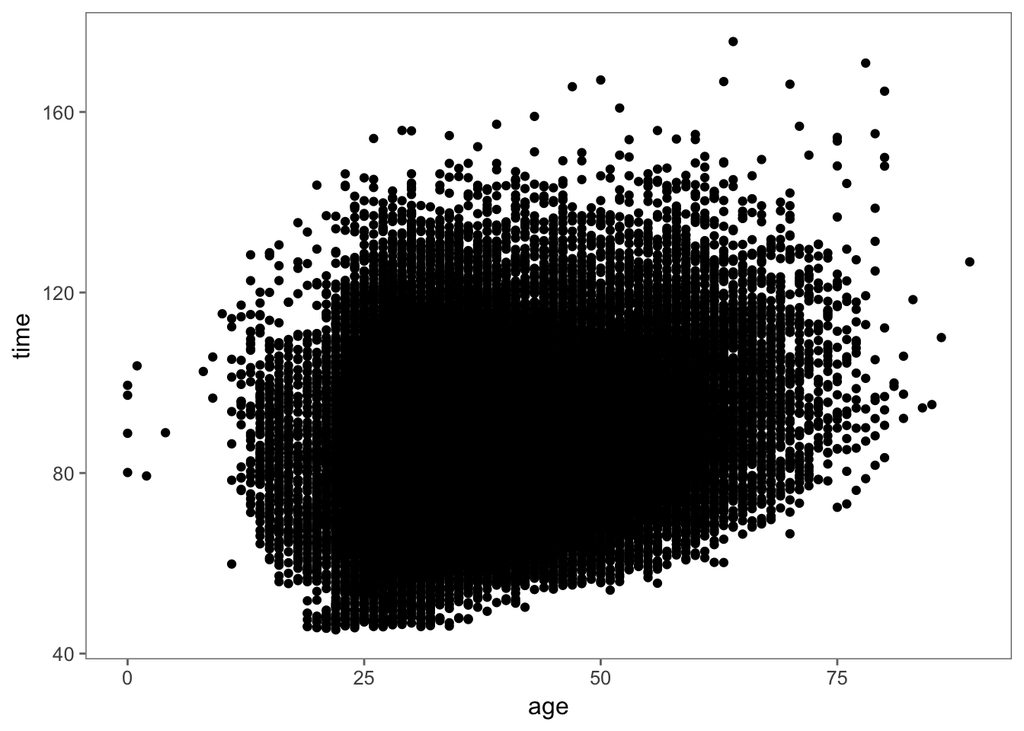

```r
ggplot(men_df, aes(age, time)) +
  geom_point()
```

The resulting plot appears in Figure @ref(fig:scatterplot-default). Most of the points appear as a black blob in the scatter plot because so many points have been plotted on top of each other. The shape of the distribution is obscured because we cannot see which regions of the (age, run time) space are more densely populated. Notice also the vertical stripes in the plot. These are the result of runner’s age being reported to the nearest year, which results in more over plotting. In the next section, we consider a few alterations to this default scatter plot that address the problem of over plotting.

## Making Plots with Many Observations

There are several modifications we can make to the plot in Figure @ref(fig:scatterplot-default) to ameliorate the effect of over plotting. We can reduce the size of the plotting symbol, use transparent colors for the plotting symbol, and add a small amount of random noise to the age variable. Alternatively, we can create a plot that reveals a smoothed version of the density of the points in each region. We can also make a series of boxplots instead of a scatter plot. We demonstrate each of these approaches in this section.

(#fig:scatterplot-fixed)Revised Scatter Plot of Male Runners. This plot revises the simple scatter plot by changing the plotting symbol from a circle to a point, reducing the size of the plotting symbol, using a transparent color for the points, and adding a small amount of random noise to age. Now we see the shape of the high density region containing most of the runners and the slight upward trend of time with increasing age.

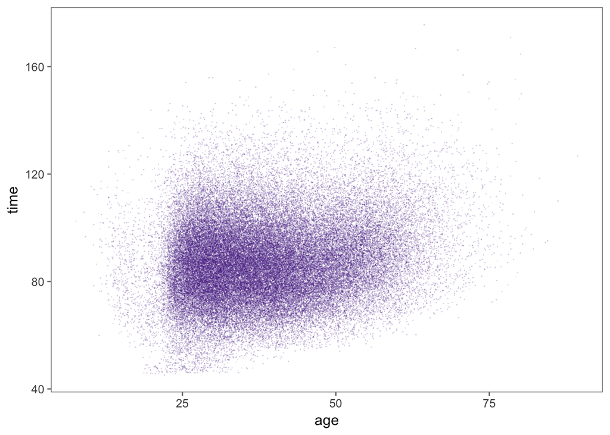

```r
men_df %>%
  filter(age > 5) %>%
  ggplot(aes(age, time)) +
  geom_jitter(shape = '.', size = 2, alpha = 0.2, height = 0, width = 0.5, color = '#54278f')
```

Our first plot appears in Figure @ref(fig:scatterplot-fixed). This plot is much improved from the initial one in Figure @ref(fig:scatterplot-default). We can see where the bulk of the runners are, including what appears to be a slight upward curvature in run time as age increases and a skew distribution of run time given age. We can also see the small group of runners with very fast run times.

(#fig:scatterplot-smooth)Smoothed Scatter Plot of Male Runners Race Times vs. Age. This plot offers an alternative to the scatter plot that uses jittering and transparent color to ameliorate the over plotting. Here there is no need to jitter age because the smoothing action essentially does that for us by spreading an individual runner’s (age, run time) pair over a small region. The shape of the high density region has a very similar shape to the earlier plot.

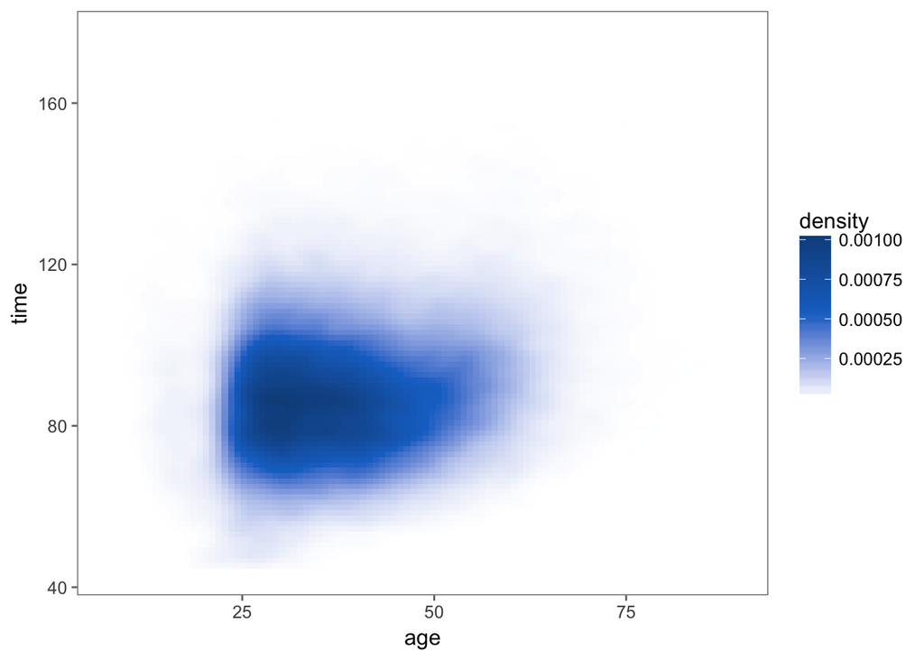

```r
men_df %>%
  filter(age > 5) %>%
  ggplot(aes(age, time)) +
  stat_density_2d(aes(fill = ..density..), geom = 'raster', contour = FALSE) +
  scale_fill_gradientn(colors = c('white', 'dodgerblue3', 'dodgerblue4'), values = c(0, 0.5, 1))
```

The smoothed two-dimensional density plot in Figure @ref(fig:scatterplot-smooth) shows a very similar shape to our plot in Figure @ref(fig:scatterplot-fixed).

A very different approach to these scatter plots is to graphically display summary statistics of run time for subgroups of runners with roughly the same age. Here, we group the runners into 10-year age intervals and plot the summaries for each subgroup in the form of a boxplot (see Figure @ref(fig:boxplots-age)). With these side-by-side boxplots, the size of the data does not obscure the main features, e.g., the quartiles and tails for an age group. To make these boxplots, we categorize age using the `cut()` function. We first remove those runners under 15 or who have unrealistic run times. Then we categorize age with

```r
men_df_agecat <- men_df %>%
  filter(time > 30, !is.na(age), age > 15) %>%
  mutate(age_cat = cut(age, breaks = c(seq(15, 75, 10), 90)))

table(men_df_agecat$age_cat)
```

```
##
## (15,25] (25,35] (35,45] (45,55] (55,65] (65,75] (75,90]
##    5804   25434   20535   12212    5001     752      69
```

This new variable, `age_cat`, is a factor that categorizes age into 10-year intervals with the exception of all of those over 75 being lumped together into one interval.

We see in Figure @ref(fig:boxplots-age) that we have created a series of boxplots rather than a scatter plot. We observe in this plot that the upper quartile increases faster with age than the median and lower quartile. In the next section, we try summarizing this relationship between age and run time more formally.

(#fig:boxplots-age)Side-by-Side Boxplots of Male Runners’ Run Time vs. Age. This sequence of boxplots shows the quartiles of time for men grouped into 10-year age intervals. As age increases, all the quartiles increase. However, the box becomes asymmetrical with age, which indicates that the upper quartile increases faster than the median and lower quartile.

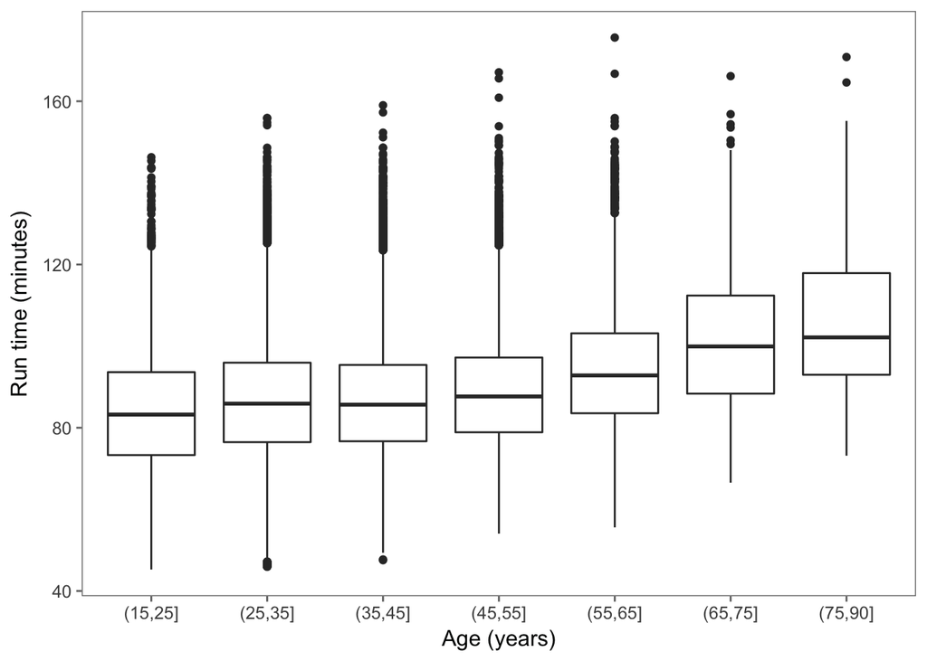

```r
men_df_agecat %>%
  ggplot(aes(age_cat, time)) +
  geom_boxplot() +
  labs(x = 'Age (years)', y = 'Run time (minutes)')
```

## Fitting Models to Average Performance

As seen in Figure @ref(fig:boxplots-age), the average performance seems to curve upward with age. A simple linear model may be inadequate to describe this relationship. To see how well the simple linear model captures the relationship (or not) between run time and age, we fit the model with

```r
lm_age <- lm(time ~ age, data = men_df_agecat)
```

The `lm()` function performs least squares to find the best fitting line to our data, which we see has the following intercept and slope:

```r
lm_age$coefficients
```

```
## (Intercept)         age
##  78.7570864   0.2252816
```

We have assigned the return value from `lm()` to `lm_age`. This object contains the coefficients from the fit, predicted values, residuals, and other information about the linear least squares fit of run time to age. We can retrieve a brief summary of the fit with a call to `summary()` as follows:

```r
summary(lm_age)
```

```
##
## Call:
## lm(formula = time ~ age, data = men_df_agecat)
##
## Residuals:
##     Min      1Q  Median      3Q     Max
## -40.333 -10.220  -0.952   9.102  82.425
##
## Coefficients:
##              Estimate Std. Error t value Pr(>|t|)
## (Intercept) 78.757086   0.207692  379.20   <2e-16 ***
## age          0.225282   0.005169   43.58   <2e-16 ***
## ---
## Signif. codes:  0 '***' 0.001 '**' 0.01 '*' 0.05 '.' 0.1 ' ' 1
##
## Residual standard error: 14.77 on 69805 degrees of freedom
## Multiple R-squared:  0.02649,    Adjusted R-squared:  0.02647
## F-statistic:  1899 on 1 and 69805 DF,  p-value: < 2.2e-16
```

To help us assess how well the simple linear model fits the data we plot the residuals against age. As with the original scatter plot of run time against age, we need to address the issue of over plotting. Further, to help us see any curvature in the residuals, we add to the plot a horizontal line at 0. We do this with

```r
p <- men_df_agecat %>%
  modelr::add_residuals(lm_age) %>%
  ggplot(aes(age, resid)) +
  stat_density_2d(aes(fill = ..density..), geom = 'raster', contour = FALSE) +
  scale_fill_gradientn(colors = c('white', 'dodgerblue3', 'dodgerblue4'), values = c(0, 0.5, 1)) +
  geom_hline(yintercept = 0, color = 'navy')
```

To help us further discern any pattern in the residuals, we augment this residual plot with a smooth curve of local averages of the residuals from the fit. That is, for a particular age, say 37, we take a weighted average of the residuals for those runners with an age in a small neighborhood of 37. Such a locally fitted curve allows us to better see deviations in the pattern of residuals.

(#fig:residuals-lm)Residual Plot from Fitting a Simple Linear Model of Performance to Age. Shown here is a smoothed scatter plot of the residuals from the fit of the simple linear model of run time to age for male runners who are 15 to 80 years old. Overlaid on the scatter plot are two curves. The “curve” in dark blue is a solid horizontal line at $y = 0$. The red dashed curve is a local smooth of the residuals.

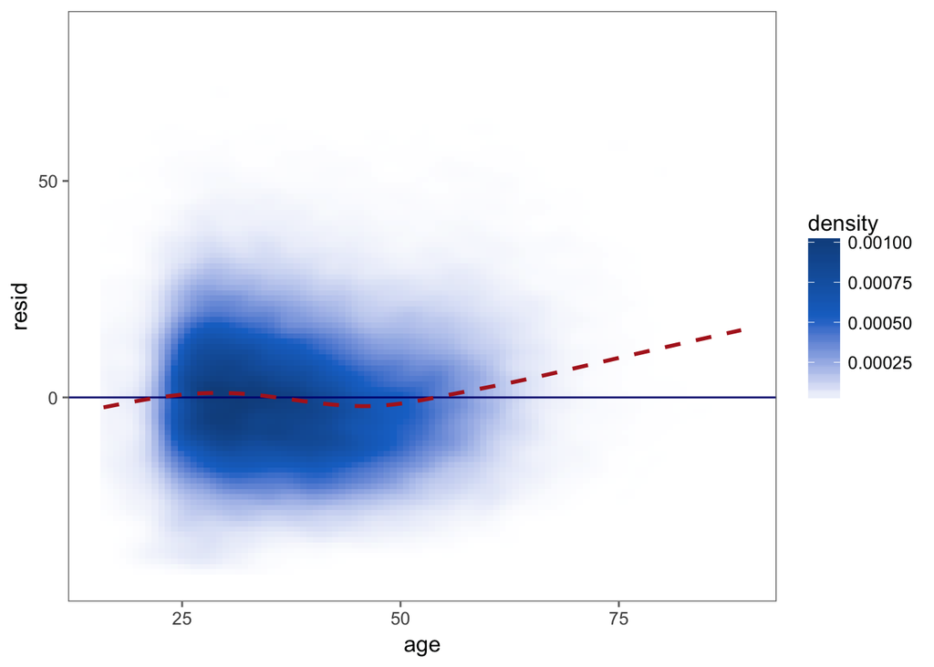

```r
p + geom_smooth(se = FALSE, linetype = 'dashed', color = 'firebrick')
```

The augmented smoothed scatter plot appears in Figure @ref(fig:residuals-lm). We see that the simple linear model tends to underestimate the run time for men over 60. This confirms our observations from the boxplot and smooth scatter plot of the nonlinear trend in run time. The simple linear model is not able to capture the change in performance with age.

We consider two approaches to a more complex fit: a piecewise linear model and a nonparametric smooth curve. For the latter, we simply take local weighted averages of time as age varies, just as we smoothed the residuals from the linear fit. We use `loess()` to do this with

```r
men_res_lo <- loess(time ~ age, data = men_df_agecat)
```

and we make predictions for all ages ranging from 20 to 80 with

```r
age20to80 <- 20:80
men_res_lo_pr <- predict(men_res_lo, data.frame(age = age20to80))
```

The curve appears in Figure @ref(fig:piecewise-fits).

Next we fit a piecewise linear model, which consists of several connected line segments. This is similar to the idea of the locally smoothed curve from `loess()` in that it allows us to bend the line at certain points to better fit the data. The difference is that the fit must be linear between the hinges. We place hinges at 30, 40, 50, and 60 and thus allow the slope of the line to change at these decade markers. The fitted “curve” appears in Figure @ref(fig:piecewise-fits).

How do we fit such a model to our data? Before we fit the full piecewise model, we consider a simpler model with one hinge at 50. We first create an `over50` variable that takes on the value 0 for ages 50 and under and otherwise holds the number of years over 50, e.g. 1 for someone who is 51, 2 for someone who is 52, and so on. If our fit is $a + b \times \textrm{age} + c \times \textrm{over50}$ then for an age below 50 this is simply $a + b \times \textrm{age}$ and for an age over 50 it is equivalent to $(a - 50c) + (b + c) \textrm{age}$. We see that the coefficient $c$ is the change in the slope from below 50 to above 50, and the intercept makes the line segments connect.

Our first task then is to create this over50 variable. We use the `pmax()` function, which performs an element-wise or “parallel” maximum. We find the maximum of each element of `men_df$age - 50` and 0 with

```r
over50 <- pmax(0, men_df_agecat$age - 50)
```

We then fit this augmented model as follows.

```r
lm_over50 <- lm(time ~ age + over50, data = men_df_agecat)
summary(lm_over50)
```

```
##
## Call:
## lm(formula = time ~ age + over50, data = men_df_agecat)
##
## Residuals:
##     Min      1Q  Median      3Q     Max
## -40.265 -10.098  -0.882   9.061  79.043
##
## Coefficients:
##              Estimate Std. Error t value Pr(>|t|)
## (Intercept) 82.754071   0.265035  312.24   <2e-16 ***
## age          0.105720   0.007147   14.79   <2e-16 ***
## over50       0.563573   0.023367   24.12   <2e-16 ***
## ---
## Signif. codes:  0 '***' 0.001 '**' 0.01 '*' 0.05 '.' 0.1 ' ' 1
##
## Residual standard error: 14.71 on 69804 degrees of freedom
## Multiple R-squared:  0.03453,    Adjusted R-squared:  0.0345
## F-statistic:  1248 on 2 and 69804 DF,  p-value: < 2.2e-16
```

Now the slope of the line for those under 50 is less steep than in our original simple linear model, and for ages over 50, the model indicates the average man slows by 0.67 minutes, which is an additional 0.56 minutes a year compared to those under fifty.

We can create the `over30`, `over40`, etc. variables as follows:

```r
decades <- seq(30, 60, by = 10)
over_age <- map_dfc(decades, function(x) {
  name <- paste0('over', x)
  df <- data_frame(pmax(0, men_df_agecat$age - x))
  names(df) <- name
  df
})
tail(over_age)
```

```
## # A tibble: 6 x 4
##   over30 over40 over50 over60
##    <dbl>  <dbl>  <dbl>  <dbl>
## 1     36     26     16      6
## 2     11      1      0      0
## 3      9      0      0      0
## 4     26     16      6      0
## 5      5      0      0      0
## 6     18      8      0      0
```

Now that we have each of these variables, we can create the model.

```r
lm_piecewise <- men_df_agecat %>%
  bind_cols(over_age) %>%
  select(time, age, starts_with('over')) %>%
  lm(time ~ ., data = .)
summary(lm_piecewise)
```

```
##
## Call:
## lm(formula = time ~ ., data = .)
##
## Residuals:
##     Min      1Q  Median      3Q     Max
## -40.921 -10.119  -0.885   9.023  78.965
##
## Coefficients:
##              Estimate Std. Error t value Pr(>|t|)
## (Intercept) 74.228651   0.915244  81.103  < 2e-16 ***
## age          0.424283   0.033207  12.777  < 2e-16 ***
## over30      -0.477006   0.047778  -9.984  < 2e-16 ***
## over40       0.221560   0.040666   5.448  5.1e-08 ***
## over50       0.494507   0.052932   9.342  < 2e-16 ***
## over60      -0.004667   0.077637  -0.060    0.952
## ---
## Signif. codes:  0 '***' 0.001 '**' 0.01 '*' 0.05 '.' 0.1 ' ' 1
##
## Residual standard error: 14.7 on 69801 degrees of freedom
## Multiple R-squared:  0.03593,    Adjusted R-squared:  0.03586
## F-statistic: 520.2 on 5 and 69801 DF,  p-value: < 2.2e-16
```

This model has an interpretation similar to the model with just `age` and `over50`. That is, the coefficient for, say, `over40` is the change in the slope for ages in (30, 40] to ages in (40, 50].

Notice that the coefficient for `over60` is essentially 0, meaning that those over 60 do not slow down any faster than those in their fifties, i.e. about 0.494 minutes more per year for each year over 50 for a total of about 0.66 minutes for the 10-mile race per year.

How do we plot this piecewise linear function that we have fitted? As with the loess curve, we can use `predict()` to provide fitted values for each age value from 20 to 80. However, we need to provide `predict()` with all of the covariates used in making the fit, i.e., `age`, `over30`, `over40`, `over50`, and `over60`. We can create a data frame of these covariates just as we did for the full data set as follows:

```r
over_age_df <- map_dfc(decades, function(x) {
  name <- paste0('over', x)
  df <- data_frame(pmax(0, age20to80 - x))
  names(df) <- name
  df
}) %>%
  bind_cols(age = age20to80, .)
tail(over_age_df)
```

```
## # A tibble: 6 x 5
##     age over30 over40 over50 over60
##   <int>  <dbl>  <dbl>  <dbl>  <dbl>
## 1    75     45     35     25     15
## 2    76     46     36     26     16
## 3    77     47     37     27     17
## 4    78     48     38     28     18
## 5    79     49     39     29     19
## 6    80     50     40     30     20
```

Then we call `predict()` passing it the `lm` object, i.e. `lm_piecewise`, with the details of the fit and also the covariates to use to make the predictions, i.e. `over_age_df`. That is, we call `predict()` with

```r
over_age_df <- over_age_df %>% modelr::add_predictions(lm_piecewise)
```

We plot this fitted piecewise linear function and the `loess` curve with

(#fig:piecewise-fits)Piecewise Linear and Loess Curves Fitted to Run Time vs. Age. Here we have plotted the fitted curves from `loess()` and a piecewise linear model with hinges at 30, 40, 50, and 60. These curves follow each other quite closely. However, there appears to be more curvature in the over 50 loess fit that is not captured in the piecewise linear fit.

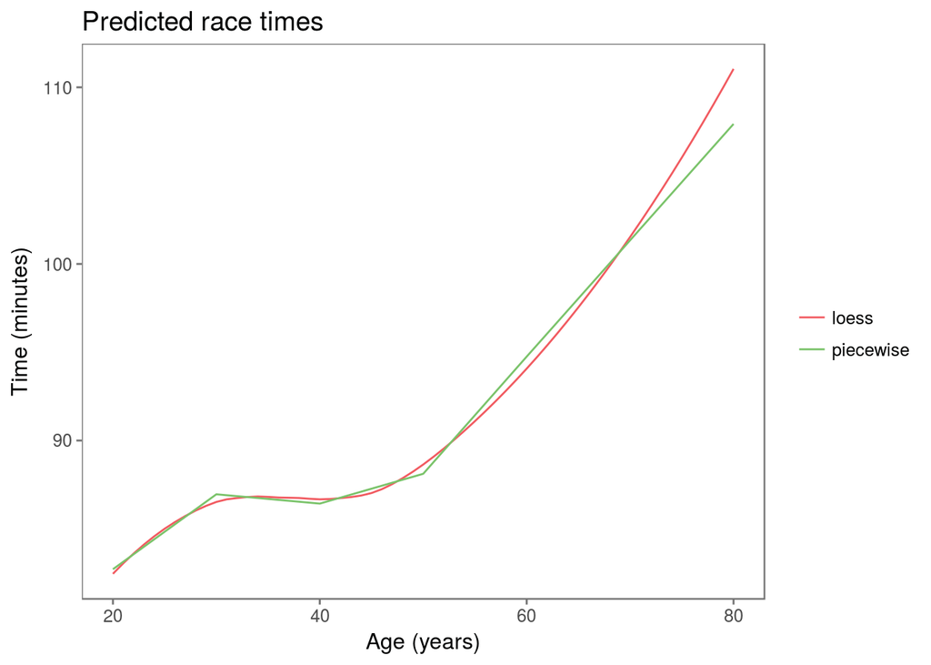

```r
over_age_df %>%
  mutate(loess = men_res_lo_pr) %>%
  gather(type, value, pred, loess) %>%
ggplot(aes(age, value, color = type)) +
  geom_line() +
  scale_color_few(name = '', labels = c('loess', 'piecewise')) +
  labs(title = 'Predicted race times', x = 'Age (years)', y = 'Time (minutes)')
```

The two fitted curves appear in Figure @ref(fig:piecewise-fits). We see that they follow each other quite closely. The main deviation is in the over 70 group. We did not include a hinge at 70 so our fitted model is unable to capture the sharper increase for those over 70. We may want to consider adding this additional hinge to our model to see if it improves the fit. It may seem that we have made great progress in modeling the average performance, but we must interpret these results with care. For example, suppose, as seems likely, that younger runners who are slow tend to drop out of racing as they age so older runners who do participate are those who tend to be faster. This can bias our estimate of how running speed changes with age. Additionally, these data consist of 14 cross-sectional snapshots of runners. We might ask ourselves whether or not the composition of the participants has changed over this time period. These concerns are the topics of the next two sections.

## Cross-Sectional Data and Covariates

In our earlier analysis, we examined the average performance for runners of different ages. That is, we looked at average performance for, e.g., 30-39 year olds and 40-49 year olds in the Cherry Blossom road race. However, we have not seen how a runner’s performance changes as he or she ages. These two groups (30-39 and 40-49 year olds) are composed of different people and if these groups of people differ from each other in some significant ways, e.g., those in their 30s are more likely to be world class runners and those in their 40s are more likely to be local amateur athletes, then we might be misled by comparing these two group’s average performances. To further complicate the matter, we have data from 14 different races so we are also averaging across the participants in these different races. We expect the average performances to be the same across the years. However, each year we have a self-selected group of participants, and we might wonder whether the composition of the participants has changed over the years. If it has, that could further complicate inference.

We know that the Cherry Blossom 10-mile run has been increasingly popular. Figure @ref(fig:runner-count) indicates that the number of male runners has more than doubled over the 14 years. It seems reasonable to question if the demographics of the participants have changed over this time period.

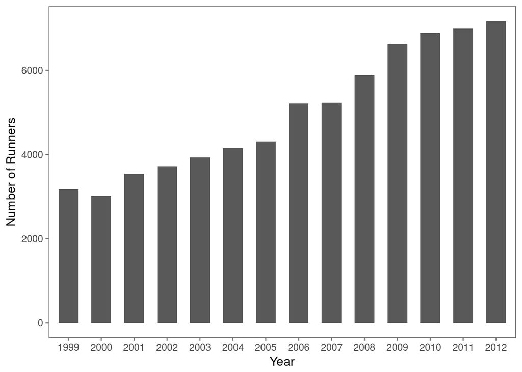

```r
men_df_agecat %>%
  ggplot(aes(factor(year))) +
  geom_bar(width = 0.6) +
  labs(x = 'Year', y = 'Number of Runners')
```

Historically, the race was used as a preparation for the Boston Marathon. The fastest runners in the Cherry Blossom primarily come from Ethiopia, Kenya, and Tanzania. And, their times are within a minute or two of the world record of 44:24 set in 2005 by Haile Gebrselassie from Ethiopia, who was 32 at the time (see http://inglog.com/tools/world-records/). Professional runners continue to compete in the Cherry Blossom road race.

Let’s compare the distribution of performance for the earliest and latest years, i.e., the 1999 and 2012 races. We see below that while the fastest man has gotten faster from 1999 to 2012, the quartiles of the 2012 distribution are each about 3 minutes slower compared to 1999:

```r
men_df_agecat %>%
  filter(year == 1999) %>%
  select(time) %>%
  summary()
```

```
##       time
##  Min.   : 46.98
##  1st Qu.: 74.82
##  Median : 84.29
##  Mean   : 84.35
##  3rd Qu.: 93.06
##  Max.   :170.83
```

```r
men_df_agecat %>%
  filter(year == 2012) %>%
  select(time) %>%
  summary()
```

```
##       time
##  Min.   : 45.25
##  1st Qu.: 77.57
##  Median : 87.47
##  Mean   : 88.44
##  3rd Qu.: 97.78
##  Max.   :150.98
```

Could it be that the men competing in 2012 are older and therefore slower than their counterparts in 1999? We can compare the age distributions of the runners in the two races.

(#fig:density-twoyears)Density Curves for the Age of Male Runners in 1999 and 2012. These two density curves have quite different shapes. The 1999 male runners have a broad, nearly flat mode where they are roughly evenly distributed in age from 28 to 45. In contrast, the 2012 runners are younger with a sharper peak just under 30 years and a skew right distribution.

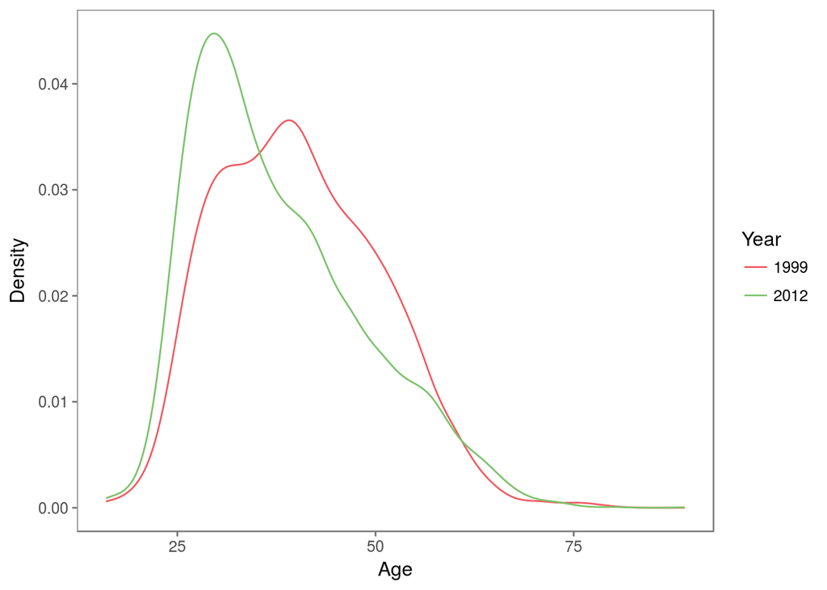

```r
men_df_agecat %>%
  filter(year %in% c(1999, 2012)) %>%
  ggplot(aes(age, color = factor(year))) +
  geom_line(stat = 'density') +
  scale_color_few(name = 'Year') +
  labs(x = 'Age', y = 'Density')
```

The density curves in Figure @ref(fig:density-twoyears) are surprising. The males in 2012 are not older. In fact, the opposite is the case. There are many more younger men in 2012 in comparison to 1999, as evidenced by the sharp peak in the 2012 distribution at about 30. We can also compare these two distributions with a quantile-quantile plot (see Figure @ref(fig:age-qq)). The difference in performance between 1999 and 2012 is more subtle than having an aging population of runners. We need to control the covariates, age and year, simultaneously when we analyze race performance.

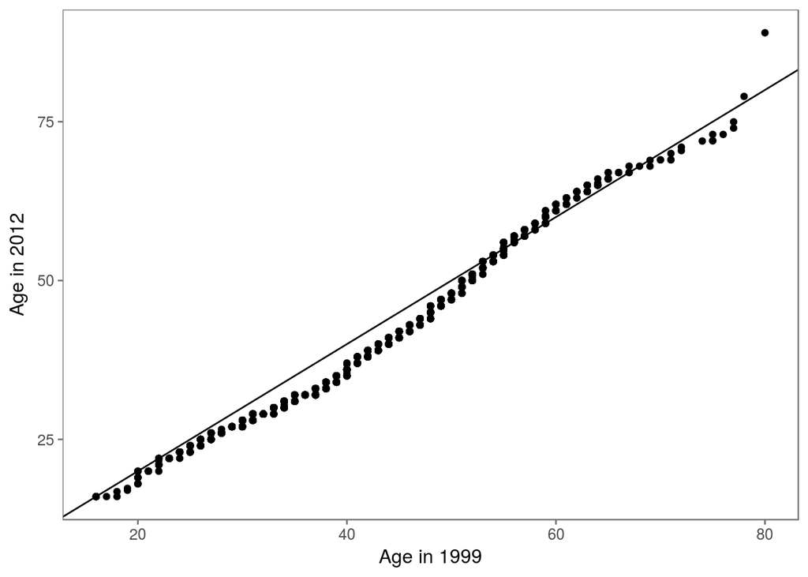

```r
pts <- qqplot(men_df_agecat$age[men_df_agecat$year == 1999],
              men_df_agecat$age[men_df_agecat$year == 2012],
              plot.it = FALSE) %>% as_data_frame()
pts %>%
  ggplot(aes(x, y)) +
  geom_point() +
  geom_abline(slope = 1, intercept = 0) +
  labs(x = 'Age in 1999', y = 'Age in 2012')
```

In the previous chapter, we saw how the average performance was flat for runners in their 30s and rose slightly in the 40s and more sharply in the 50s and 60s. We make separate smooth curves of time versus age for the 1999 and 2012 runners and plot them together as follows:

(#fig:loess-twoyears)Loess Curves Fit to Performance for 1999 and 2012 Male Runners. This loess fit of run time to age for 2012 male runners sits above the fit for 1999 male runners. The gap between these curves is about 5 minutes for most years. The exception is in the late 40s to early 60s where the curves are within 2–3 minutes of each other. Both curves have a similar shape.

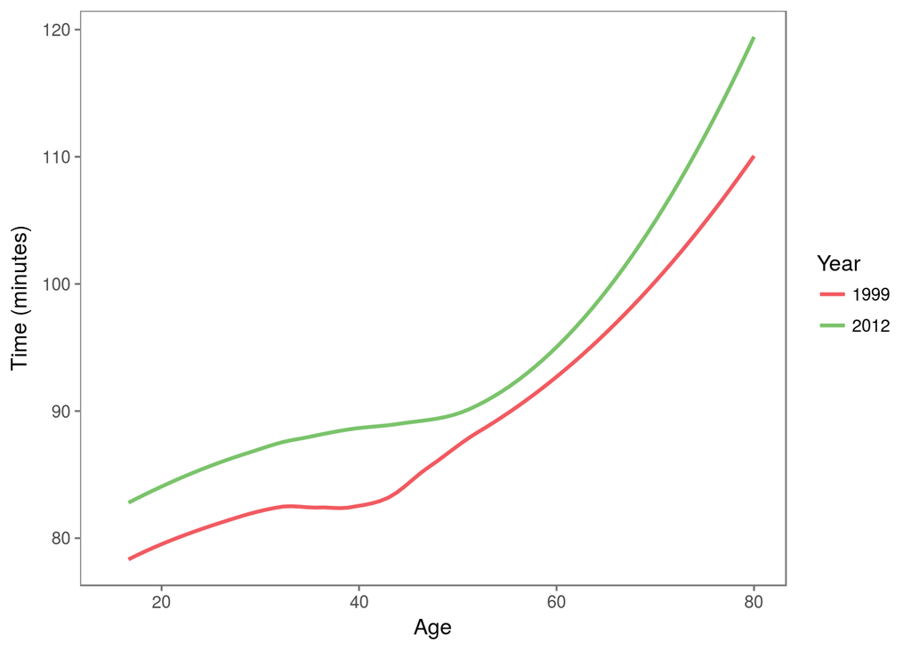

```r
p <- men_df_agecat %>%
  filter(year %in% c(1999, 2012)) %>%
  ggplot(aes(age, time, color = factor(year))) +
  geom_smooth(method = 'loess', se = FALSE, fullrange = TRUE) +
  scale_color_few(name = 'Year') +
  xlim(c(15, 80)) +
  labs(x = 'Age', y = 'Time (minutes)')
p
```

We see in Figure @ref(fig:loess-twoyears) that the two curves are similar in shape but the curve for 2012 is higher than the 1999 curve. There appears to be a consistent difference between these two groups of runners. Figure @ref(fig:loess-difference) shows the difference in predicted run times for these two curves. This difference narrows to 2 minutes for men in their 50s and gradually widens for men in their 60s, 70s, and 80s from 2.5 to 8.5 minutes. We leave it as an exercise to compare the run time age relationship for all 14 years of data.

(#fig:loess-difference)Difference between Loess Curves. This line plot shows the difference between the predicted run time for 2012 and 1999 male runners.

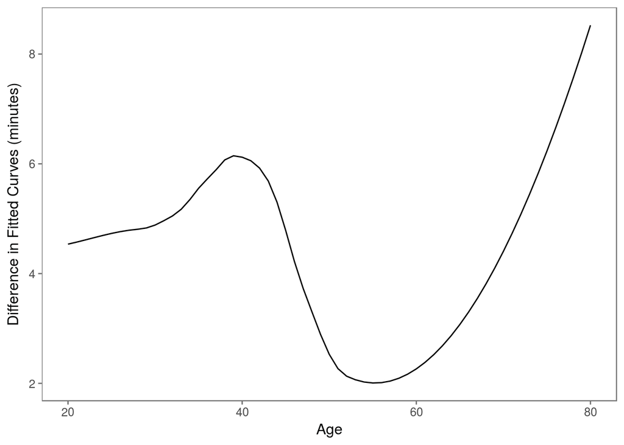

```r
lo_pr_99 <- predict(loess(time ~ age,
                          data = men_df_agecat,
                          subset = men_df_agecat$year == 1999),
                    data_frame(age = age20to80))
lo_pr_12 <- predict(loess(time ~ age,
                          data = men_df_agecat,
                          subset = men_df_agecat$year == 2012),
                    data_frame(age = age20to80))
data_frame(age = age20to80, diff = lo_pr_12 - lo_pr_99) %>%
  ggplot(aes(age, diff)) +
  geom_line() +
  labs(x = 'Age', y = 'Difference in Fitted Curves (minutes)')
```

We mention one last idea for comparing these two distributions of runners, and we leave it to the exercises to carry out this comparison. In track, there is a performance standard called age grading that measures an individual’s performance based on his or her age. It normalizes the individual’s run time by the world record for that distance for that age group. Since the fastest runners in the Cherry Blossom road race perform close to the world record, we might use the fastest runner in each age category to normalize the times. To minimize the year-to-year fluctuations, we can smooth the fastest times and use these smoothed times to normalize each runner’s time. When we do this, we find the age graded performances roughly follow the Normal distribution. However, the 1999 runners tend to be better than their 2012 counterparts as evidenced by the peak at 1.4 rather than 1.5 and a smaller IQR.

The run time distribution appears to have changed over the years, and this points out the main issue with cross-sectional studies. However, there is an advantage to having 14 years’ worth of race results. It is possible that some runners have participated in the race over several years and we can study how each runner’s performance changes as he or she grows older. In order to do this, we need to connect runners across the years.

# Constructing a Record for an Individual Runner across Years

We want to match records from runners who have participated in more than one Cherry Blossom run. The race results do not have unique identifiers for each person so we need to construct these from the information we have on each race entrant. Ideally we use all of the information, i.e. the runner’s name, home, age, race time, and the year of the race. However, if this information is reported inconsistently from one year to the next, then this can reduct the number of matches. On the other hand, even using all of this information we may be incorrectly matching records from two different athletes. Whatever approach we devise will not be completely accurate, and the purpose of this section is to investigate several possibilities and settle on one that we think is reasonable.

We consider the following questions:

- How many entrants are there over the 14 years?
- How many unique names are there among these entrants?
- How many names appear twice, 3 times, 4 times, etc. and what name occurs most often?
- How often does a name appear more than once in a year?

Answering these questions gives us a sense of the magnitude of the matching problem. Additionally, we consider how to improve the matching by cleaning the `name` and `home` values. *The book describes trimming white space and fixing inconsistent capitalization here. We have already taken care of that in Chapter @ref(cleaning).*

Now we can begin to answer the questions about the uniqueness of the names. We do this by examining summary statistics and sets of records.

How many entrants are there over the 14 races? We use `length()` to find out:

```r
length(men_df_agecat$name)
```

```
## [1] 69807
```

Recall, we have dropped those records with a run time under 30 minutes, and age under 16.

How many unique names are there?

```r
length(unique(men_df_agecat$name))
```

```
## [1] 39202
```

How many names appear once, twice, etc.? We can determine this by two calls to `table()`, i.e.

```r
table(table(men_df_agecat$name))
```

```
##
##     1     2     3     4     5     6     7     8     9    10    11    12
## 25490  6863  3029  1537   877   509   310   200   136    89    56    39
##    13    14    15    16    17    18    20    33
##    36    17     7     2     1     2     1     1
```

What does this table tell us? We see that over 6000 names appear 2 times throughout the 14 races. One name appears 33 times, and we know this name must correspond to at least 3 people because we have only 14 years of race results.

```r
head(sort(table(men_df_agecat$name), decreasing = TRUE), 1)
```

```
## Michael Smith
##            33
```

Let’s examine other information about these 33 Michael Smiths. We extract them from our data frame with

```r
msmith <- men_df_agecat %>% filter(name == 'Michael Smith')
```

The hometowns include

```r
msmith %>% count(home) %>% arrange(desc(n)) %>% head()
```

```
## # A tibble: 6 x 2
##             home     n
##            <chr> <int>
## 1   Arlington VA     6
## 2  Washington DC     6
## 3   Annapolis MD     3
## 4 Chevy Chase MD     3
## 5   Annandale VA     2
## 6    Bethesda MD     2
```

Thinking ahead, we might ask: can we do more cleaning to potentially improve the matching? We have already made the capitalization more consistent. Additionally, we can remove punctuation such as a period after someone’s middle initial and any stray commas. We do this in one call to `gsub()` with

```r
men_df_agecat <- men_df_agecat %>%
  mutate(name = str_replace_all(name, '[,.]', ''))
```

With so many duplicate names, let’s figure out how many times a name appears in the same year. We can create a table of year-name combinations with

```r
tab_name_yr <- table(men_df_agecat$year, men_df_agecat$name)
```

and then call `max()` to find the cell in the table with the greatest count, i.e.,

```r
max(tab_name_yr)
```

```
## [1] 5
```

Is this Michael Smith again? It takes a bit of work to find the name associated with this maximum. The table saved in `tab_name_yr` is of class `table`, which we see is a numeric vector with 3 attributes, `dim`, `dimname`, and `class`. Calls to `class()`, `mode()`, and `attributes()` help figure this out, i.e.,

```r
class(tab_name_yr)
```

```
## [1] "table"
```

```r
mode(tab_name_yr)
```

```
## [1] "numeric"
```

```r
names(attributes(tab_name_yr))
```

```
## [1] "dim"      "dimnames" "class"
```

There are several implications of this data structure. First, some matrix functions work on a `table`, e.g. we can call `dim()` and `colnames()` and find

```r
dim(tab_name_yr)
```

```
## [1]    14 39138
```

```r
head(colnames(tab_name_yr), 3)
```

```
## [1] "8Illiam Maury" "Aakar Jain"    "Aakash Bhatt"
```

Notice we have uncovered another piece of messy data! To find out which cell has a count of 5, we can use `which()`, but to find the row and column location, we need to include the `arr.ind` argument in our call. That is,

```r
idx_max <- which(tab_name_yr == max(tab_name_yr), arr.ind = TRUE)
idx_max
```

```
##      row   col
## 2012  14 25458
```

Finally, we locate the name(s) with

```r
colnames(tab_name_yr)[idx_max[2]]
```

```
## [1] "Michael Brown"
```

It’s Michael Brown, not Michael Smith!

We can also derive an approximation to year of birth because we have the runner’s age and the year of the race. The difference between these two is an approximation to age because the race is held on the first Sunday in April every year. Those runners who have a birthday in the first 7 days of April may have their age reported inconsistently from one race year to the next. What fraction of the records can we expect to have this problem? We create a new variable `yob` in our data frame with

```r
men_df_agecat <- men_df_agecat %>%
  mutate(yob = year - age)
```

Let’s look closer at the values for these new and cleaned variables for the Michael Browns in our data frame. We do this with

```r
men_df_agecat %>%
  filter(name == 'Michael Brown') %>%
  arrange(yob) %>%
  select(year, name, home, yob, time)
```

```
## # A tibble: 18 x 5
##     year          name           home   yob      time
##    <int>         <chr>          <chr> <dbl>     <dbl>
##  1  2000 Michael Brown      Tucson AZ  1939  96.88333
##  2  2010 Michael Brown  North East MD  1953  92.26667
##  3  2011 Michael Brown  North East MD  1953  85.95000
##  4  2012 Michael Brown  North East MD  1953  88.43333
##  5  2009 Michael Brown      Oakton VA  1957  99.73333
##  6  2008 Michael Brown     Ashburn VA  1958  93.73333
##  7  2009 Michael Brown     Ashburn VA  1958  88.56667
##  8  2010 Michael Brown     Ashburn VA  1958  99.75000
##  9  2012 Michael Brown      Reston VA  1958  89.95000
## 10  2006 Michael Brown    Chevy Chase  1966  84.56667
## 11  2010 Michael Brown Chevy Chase MD  1966  79.35000
## 12  2012 Michael Brown Chevy Chase MD  1966  95.81667
## 13  2004 Michael Brown  Berryville VA  1978  76.31667
## 14  2008 Michael Brown   Arlington VA  1984  84.68333
## 15  2010 Michael Brown    New York NY  1984 110.88333
## 16  2011 Michael Brown   Arlington VA  1984  81.70000
## 17  2012 Michael Brown   Arlington VA  1984  70.93333
## 18  2012 Michael Brown     Clifton VA  1988  84.88333
```

What observations can we make about these various `Michael Brown` rows?

We summarize our various observations to make a first attempt to create an identifier for individuals. We might paste together the cleaned name and the derived year of birth. We do this with

```r
men_df_agecat <- men_df_agecat %>%
  mutate(id = paste(name, yob, sep = '_'))
```

We have ignored the information provided by the hometown and the run times and so have created the least restrictive identifier.

Since our goal is to study how an athlete’s time changes with age, let’s focus on those IDs that appear in at least 8 races. To do this, we first determine how many times each `id` appears in `men_df_agecat` with

```r
races <- men_df_agecat %>% count(id)
```

Then we select those IDs that appear at least 8 times with

```r
races8 <- races %>% filter(n >= 8) %>% .$id
```

and we subset `men_df_agecat` to select the entries belonging to these identifiers with

```r
men8 <- men_df_agecat %>% filter(id %in% races8)
```

Finally, we organize the data frame so that entries with the same `id` are contiguous. This makes it easier to manually examine records, etc. We can do this with

```r
men8 <- men8 %>% arrange(id)
```

An alternative organization for the data is to store them as a list with an element for each ID in `races8`. In this list, each elmeent is a dat frame containing only those results for the records with the same ID. We can create this list with

```r
men8L <- men8 %>% group_by(id) %>% nest() %>% .$data
names(men8L) <- races8
```

Which data structure is preferable? That depends on what we want to do with the data. In the following we show how to accomplish a task using both approaches to help make a comparison between the two structures. In the next section, we find it easiest to work with the list of data frames as we often need to apply a function of multiple arguments to each runner’s entries.

How many IDs do we have left?

```r
length(unique(men8$id))
```

```
## [1] 480
```

This is the same as `length(men8L)`. We might also want to discard matches if the performance varies too much from year to year. How large a fluctuation would make us think that we have mistakenly connected two different people? Of course, we don’t want to bias our results by eliminating an individual whose run times vary a lot. Let’s look at a few records where the year-to-year difference in time exceeds, say, 20 minutes. We determine which satisfy this constraint with

```r
gap_time <- map_lgl(men8L, ~ any(abs(diff(.$time)) > 20))
```

How many of these runners have gaps of more than 20 minutes?

```r
sum(gap_time)
```

```
## [1] 49
```

Slightly reformatted displays of the first two of these athletes are

```r
map(men8L[gap_time][1:2], ~ .[ ,c('year', 'home', 'name', 'yob', 'time')])
```

```
## $`Abiy Zewde_1967`
## # A tibble: 12 x 5
##     year                 home       name   yob      time
##    <int>                <chr>      <chr> <dbl>     <dbl>
##  1  1999      Gaithersburg MD Abiy Zewde  1967  96.51667
##  2  2000   Montgomery Vill MD Abiy Zewde  1967  96.63333
##  3  2001   Montgomery Vill MD Abiy Zewde  1967  89.10000
##  4  2002   Montgomery Vill MD Abiy Zewde  1967 123.00000
##  5  2003      Gaithersburg MD Abiy Zewde  1967  97.68333
##  6  2004   Montgomery Vill MD Abiy Zewde  1967 100.36667
##  7  2006         Gaithersburg Abiy Zewde  1967 108.40000
##  8  2008   Montgomery Vill MD Abiy Zewde  1967  98.78333
##  9  2009 Montgomery Villag MD Abiy Zewde  1967  98.50000
## 10  2010 Montgomery Villag MD Abiy Zewde  1967  99.91667
## 11  2011 Montgomery Villag MD Abiy Zewde  1967 113.10000
## 12  2012 Montgomery Villag MD Abiy Zewde  1967  84.88333
##
## $`Adam Hughes_1978`
## # A tibble: 8 x 5
##    year          home        name   yob      time
##   <int>         <chr>       <chr> <dbl>     <dbl>
## 1  2005 Washington DC Adam Hughes  1978  80.38333
## 2  2006    Washington Adam Hughes  1978  85.16667
## 3  2007 Washington DC Adam Hughes  1978  77.78333
## 4  2008 Washington DC Adam Hughes  1978  74.23333
## 5  2009 Washington DC Adam Hughes  1978 108.06667
## 6  2010 Washington DC Adam Hughes  1978 103.06667
## 7  2011 Washington DC Adam Hughes  1978  77.11667
## 8  2012 Washington DC Adam Hughes  1978  77.76667
```

The name `Abiy Zewde` seems unusual enough to most likely be the same person participating in 12 of the 14 races even though the hometown has changed over the years and the race results differ by nearly 40 minutes with one of the fastest times being the most recent when he was 45 years old.

Do we want to further restrict our matching to those with the same hometown? This eliminates, e.g., the `Abiy Zewde` records, even though we’re quite certain the records all belong to the same individual. We could identify the mismatches and manually examine them for potentially false matches. We need to eliminate the state abbreviation from the end of those records that have one because the 2006 records do not have it. We can substitute a blank followed by 2 letters occurring at the end of the string with an empty string, i.e.

```
gsub("[[:blank:]][a-z]{2}$", "", home)
```

This may result in matches that are too liberal, e.g. matching Springfield IL and Springfield MA. We leave it as an exercise to determine how to limit the matches to those where the entries have the same hometown and to assess whether this additional restriction should be added to the matching process.

Here, we consider a less strict matching where we match only those records that have the same values for the state of residence. To do this, we create a new variable that holds the 2 letter abbreviation for the state. We return to work with `men_df_agecat` because the data structure is simpler and we maintain consistency. We extract the last 2 characters from each home string. This is the state, if it is present. We know that in 2006, the state was not present so we set these to `NA`. For athletes who come from outside the US, we pick up the last two letters of either the country or province, but these should not dramatically affect our matches.

We first determine how many characters are in each value for home with

```r
home_len <- nchar(men_df_agecat$home)
```

Then we use it to extract the last two characters and add them back to our data frame with

```r
men_df_agecat <- men_df_agecat %>%
  mutate(state = str_sub(home, start = home_len - 1, end = home_len))
```

And, we set the 2006 values to `NA`:

```r
men_df_agecat$state[men_df_agecat$year == 2006] <- NA
```

Next, we recreate the new `id` so that it includes `state`. We do this with

```r
men_df_agecat <- men_df_agecat %>%
  mutate(id = paste(name, yob, state, sep = '_'))
```

Then, we again select those `id`s that occur at least 8 times with

```r
races <- men_df_agecat %>% count(id)
races8 <- races %>% filter(n >= 8) %>% .$id
men8 <- men_df_agecat %>% filter(id %in% races8) %>% arrange(id)
men8L <- men8 %>% group_by(id) %>% nest() %>% .$data
names(men8L) <- races8
```

In the next section we work solely with the list structure.

This addition to the runner id further redues the number of runners who havea completed 8 races, i.e.,

```r
length(races8)
```

```
## [1] 306
```

We now have 306 athletes who have the same name, year of birth, and state and who have run in 8 of the 14 races. We carry on with this set of matches we have obtained thus far, and in the next section, we examine how each runner’s performance changes as he grows older.

# Modeling the Change in Running Time for Individuals

The Cherry Blossom race results include recordings for athletes from 20 to 80 years old. However, we don’t have records for any one person that covers this 60-year span. That’s not possible because we have only 14 years of race results so we can at most observe a 20 year old until he turns 33 or an 80 year old when he was 67. This means when we examine the performance of an individual over time, we are looking at short time series that are at most 14 years long. To examine performance from 20 to 80 necessarily means that we rely on the cross-sectional aspect of the data, but there is information to be gleaned in these short time series.

It’s reasonable to imagine that over a short period of time, say 8 to 10 years, a runner’s performance is roughly linear with age. (We saw this with the piecewise linear model for the cross-sectional data). We can make plots to ascertain if this is the case. We have over 300 runners to plot so to limit the effect of over plotting, we make several plots of different subsets of the data. We begin by dividing the runners into 9 groups to make 9 plots in a 3-by-3 grid. We assign roughly the same number of runners to each group with

```r
men8 <- men8 %>%
  mutate(group = group_indices(., id) %% 9 + 1)
```

and we can plot it with one call to `ggplot()`.

(#fig:time-trends)Run Times for Multiple Races. These line plots show the times for male runners who completed at least 8 Cherry Blossom races. Each set of connected segments corresponds to the run times for one athlete. Looking at all line plots, we see a similar shape to the overall scatter plot, i.e., an upward curve with age. However, we can also see how an individual’s performance changes. For example, many middle-aged runners show a sharp increase in run time with age but that is not the case for all. Some of them improve and others change more slowly.

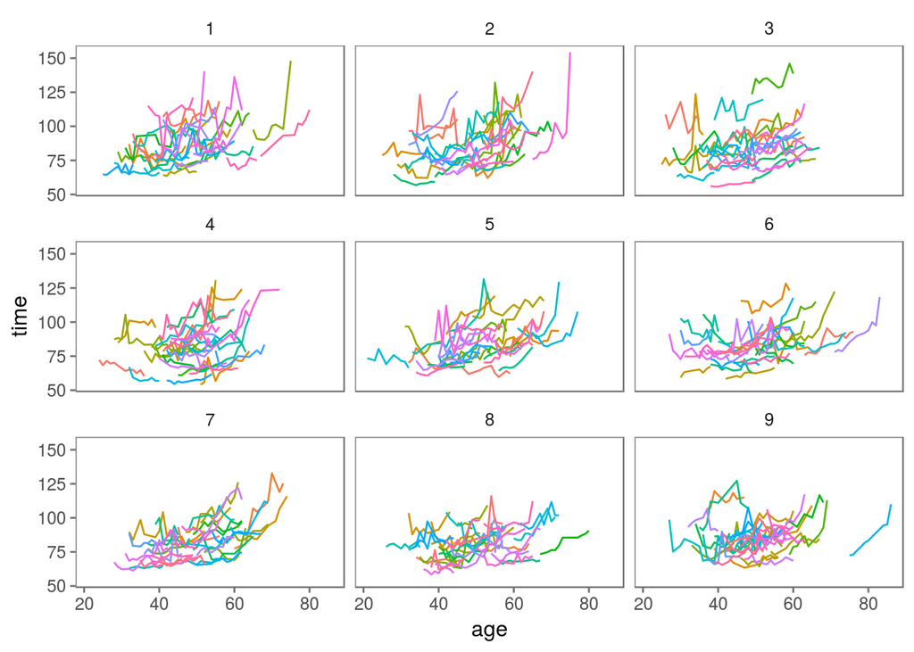

```r
ggplot(men8, aes(age, time, color = id)) +
  geom_line(show.legend = FALSE) +
  facet_wrap( ~ group)
```

In Figure @ref(fig:time-trends) we see 9 line plots, each containing about 30 athletes. Some of the athletes fluctuate quite a bit, and we might want to revisit hte notion of dropping runners that may be the combination of two different people’s records because they fluctuate more than expected. We leave this as an exercise. Otherwise, fitting a line to each individual’s performance seems a reasonable approach.

A longitudinal analysis of each individual runner implicitly controls for covariates that may influence performance, e.g. gender. One exception is the race condition in any given year – some years might be slow and some fast due to changes in the course or weather. However, it seems plausible that such an effect is uncorrelated with age and so amounts to measurement noise.

Now that we have our list of runners, we wish to fit a line to each runner’s performance. The book writes a custom function to accomplish this for each runner, but this what the `broom` package was made for.

First, let’s draw a plot with the fitted lines. As shown in Figure @ref(fig:linearfit-onegroup), these line segments seem to capture each runner’s performance.

(#fig:linearfit-onegroup)Linear Fits of Run Time to Age for Individual Runners. Here we have augmented the bottom-right line plot from earlier with the least squares fit of run time for each of the athletes. These are the 30 or so grey dashed line segments plotted on each of the individual runner’s times series.

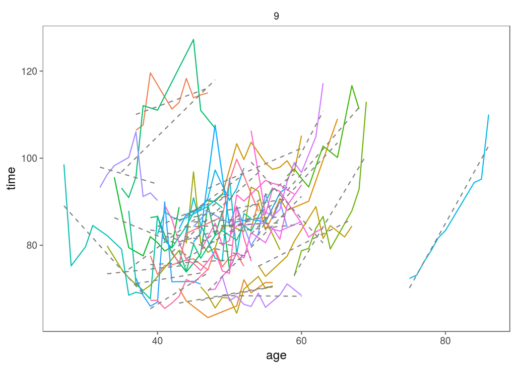

```r
men8 %>%
  filter(group == 9) %>%
ggplot(aes(age, time, color = id)) +
  geom_line(show.legend = FALSE) +
  geom_smooth(aes(group = id),
              method = 'lm',
              se = FALSE,
              color = 'grey50',
              size = 0.5,
              linetype = 'dashed',
              show.legend = FALSE) +
  facet_wrap( ~ group)
```

To examine the runner-to-runner variability, we fit lines to all 306 athletes with the following call.

```r
lm_coefs <- men8 %>%
  group_by(id) %>%
  do(fit = lm(time ~ age, data = .)) %>%
  tidy(fit)

long_coefs <- men8 %>%
  group_by(id) %>%
  summarise(med_age = median(age)) %>%
  mutate(coef = lm_coefs$estimate[lm_coefs$term == 'age'])
```

Now we have a single coefficient that represents the relationship between run time and age for each runner who ran at least 8 times (and who resided in the same state over those race years). This coefficient has units of minutes in run time for the 10-mile race per year. A positive coefficient means that the runner is slowing down by that number of minutes a year.

(#fig:long-coefs)Coefficients from Longitudinal Analysis of Athletes. This scatter plot displays the slope of the fitted line to each of the 300+ runners who competed in at least 8 Cherry Blossom road races. A negative coefficient indicates the runner is getting faster as he ages. The plot includes a least squares fitted line and a loess fitted curve. Notice that nearly all of the coefficients for those over 50 are positive. The typical size of this coefficient for a 50-year old is about one minute per year.

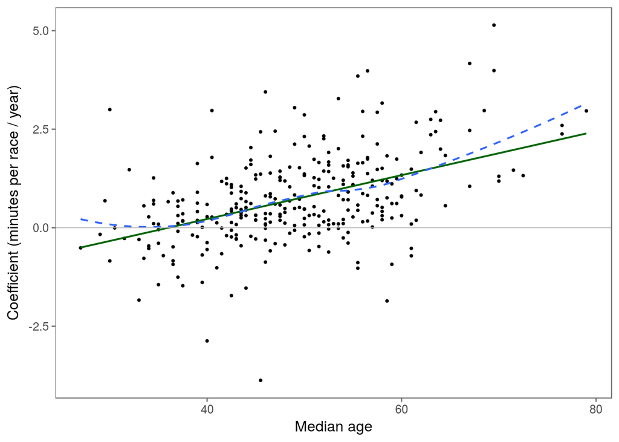

```r
ggplot(long_coefs, aes(med_age, coef)) +
  geom_point(size = 0.7) +
  geom_smooth(method = 'lm', size = 0.7, color = 'darkgreen', se = FALSE) +
  geom_smooth(method = 'loess', size = 0.7, linetype = 'dashed', se = FALSE) +
  geom_hline(yintercept = 0, color = 'grey70', size = 0.3) +
  labs(x = 'Median age', y = 'Coefficient (minutes per race / year)')
```

We see in Figure @ref(fig:long-coefs) how these coefficients vary with age. There is plenty of individual variation in performance with a few in their 50s and 60s getting faster and many in their 30s slowing down. However, we also see a relationship between age and run time. There appears to be a positive linear trend in the coefficients. We fit this with

```r
long_fit <- lm(coef ~ med_age, data = long_coefs)
summary(long_fit)
```

```
##
## Call:
## lm(formula = coef ~ med_age, data = long_coefs)
##
## Residuals:
##     Min      1Q  Median      3Q     Max
## -4.4015 -0.6317 -0.0216  0.5673  3.3337
##
## Coefficients:
##              Estimate Std. Error t value Pr(>|t|)
## (Intercept) -2.005340   0.308505  -6.500 3.28e-10 ***
## med_age      0.055663   0.006176   9.013  < 2e-16 ***
## ---
## Signif. codes:  0 '***' 0.001 '**' 0.01 '*' 0.05 '.' 0.1 ' ' 1
##
## Residual standard error: 1.009 on 304 degrees of freedom
## Multiple R-squared:  0.2109, Adjusted R-squared:  0.2083
## F-statistic: 81.23 on 1 and 304 DF,  p-value: < 2.2e-16
```

We have also plotted this fitted line along with a horizontal reference line at 0 and a smooth loess curve fit to the coefficients in Figure @ref(fig:long-coefs). This graph suggests that, on average, performance improves for people who are younger than about 35. That is, the age coefficient is negative for ages under 30. The hypothetical “average” runner who is older than 35 slows down. By age 60, the typical runner slows by about 1.3 minutes per year, about twice as fast as indicated by the cross-sectional analysis.